Bioactive Materials 6 (2021) 3782–3800

Biosynthetic scaffolds for partial meniscal loss: A systematic review from

animal models to clinical practice

F. Veronesi <sup>a</sup>, B. Di Matteo <sup>b</sup><sup>,</sup><sup>g</sup><sup>,</sup>*, N.D. Vitale <sup>b</sup><sup>,</sup><sup>c</sup>, G. Filardo <sup>d</sup><sup>,</sup><sup>e</sup><sup>,</sup><sup>f</sup>, A. Visani <sup>a</sup>, E. Kon <sup>b</sup><sup>,</sup><sup>c</sup>, M. Fini <sup>a</sup>

a *Complex Structure of Surgical Sciences and Technologies, IRCCS Istituto Ortopedico Rizzoli, Bologna, Italy*

b *Humanitas University, Department of Biomedical Sciences, Via Rita Levi Montalcini 4, 20090, Pieve Emanuele, Milan, Italy*

c *IRCCS Humanitas Research Hospital, Via Manzoni 56, 20089, Rozzano, Milan, Italy*

d *Applied and Translational Research Center, IRCCS Istituto Ortopedico Rizzoli, Bologna, Italy*

e *Orthopaedic and Traumatology Unit, Ospedale Regionale di Lugano, EOC, Lugano, Switzerland*

f *Faculty of Biomedical Sciences, Universit*`*a della Svizzera Italiana, Lugano, Switzerland*

g *First Moscow State Medical University - Sechenov University, Bol**’**shaya Pirogovskaya Ulitsa, 19c1, 119146, Moscow, Russia*

A R T I C L E I N F O

*Keywords:*

Meniscal scaffold

Meniscectomy

Osteoarthritis

Regenerative medicine

Collagen

Polyurethane

A B S T R A C T

Acute or degenerative meniscus tears are the most common knee lesions. Meniscectomy provides symptomatic

relief and functional recovery only in the short- to mid-term follow-up but significantly increases the risk of

osteoarthritis. For this reason, preserving the meniscus is key, although it remains a challenge. Allograft trans-

plants present many disadvantages, so during the last 20 years preclinical and clinical research focused on

developing and investigating meniscal scaffolds. The aim of this systematic review was to collect and evaluate all

the available evidence on biosynthetic scaffolds for meniscus regeneration both *in vivo* and in clinical studies.

Three databases were searched: 46 *in vivo* preclinical studies and 30 clinical ones were found. Sixteen natural, 15

synthetic, and 15 hybrid scaffolds were studied *in vivo*. Among them, only 2 were translated into clinic: the

Collagen Meniscus Implant, used in 11 studies, and the polyurethane-based scaffold Actifit®, applied in 19

studies. Although positive outcomes were described in the short- to mid-term, the number of concurrent pro-

cedures and the lack of randomized trials are the major limitations of the available clinical literature. Few *in vivo*

studies also combined the use of cells or growth factors, but these augmentation strategies have not been applied

in the clinical practice yet. Current solutions offer a significant but incomplete clinical improvement, and the

regeneration potential is still unsatisfactory. Building upon the overall positive results of these “old” technologies

to address partial meniscal loss, further innovation is urgently needed in this field to provide patients better joint

sparing treatment options.

**1. Introduction**

Meniscal preservation is one the pillars of “joint preserving surgery”

which aims at decreasing the need for total knee replacement [1,2]. In

fact, even though meniscectomy is shown to provide symptomatic relief

and functional recovery in the short- to mid-term follow-up, its

long-term consequences are well-known and it could be considered as

one of the “heaviest” risk factors for the onset of osteoarthritis (OA) even

in young and middle-aged patients [3,4]. The management of meniscal

damage has its own chapter in the history of orthopaedics [5] and,

surprisingly, the very first surgical treatment, described in 1874, was a

meniscal reinsertion rather than a meniscectomy [6]. Also, current

guidelines suggest saving meniscal tissue whenever possible, but not

every meniscal tear can be sutured: as a result, meniscectomy still rep-

resents the most common arthroscopic procedure performed worldwide

[7]. Meniscectomized knees undergo relevant biomechanical and kine-

matic impairment, whose entity depends on the amount of meniscal

resection: first, there is a variable loss of knee stability, both in

antero-posterior and rotational translations, associated to a reduction of

the congruency between the articular surfaces of the tibia and femur.

Subsequently, an increase in local peak contact pressure and a reduction

of joint lubrication occur, leading to a gradual cartilage damage in the

affected compartment, ultimately resulting in the onset of OA often

associated to extensive subchondral bone damage, especially in knees

Peer review under responsibility of KeAi Communications Co., Ltd.

* Corresponding author. Humanitas University, Department of Biomedical Sciences, Via Manzoni 113, 20089, Rozzano, Milan, Italy.

*E-mail address:* berardo.dimatteo@gmail.com (B. Di Matteo).

[figure not shown]

[figure not shown]

https://doi.org/10.1016/j.bioactmat.2021.03.033

Received 28 November 2020; Received in revised form 21 March 2021; Accepted 23 March 2021

presenting with varus-valgus malalignment.

Based on these premises, to address massive meniscus loss, allograft

transplantation has been introduced into clinical practice more than 30

years ago [8–12]. However, despite positive findings, the use of allo-

grafts is affected by some drawbacks, mainly related to the limited

availability of musculoskeletal tissue banks and the strict regulations on

the use of allograft existing in some countries. Furthermore, meniscal

allograft is best indicated in total or sub-total meniscectomized patients,

whereas, in the majority of cases, clinicians deal with partial meniscal

defects.

Meniscal scaffolds have been developed to address these limitations

[13]: scaffolds are biomimetic materials able to stimulate tissue repair

and regeneration by recruiting autologous stromal cells that can popu-

late the 3-dimensional architecture of the scaffold, and restore the

meniscal fibro-cartilage.

The rationale behind the development of meniscal scaffolds was

therefore to offer a treatment option for partial meniscal loss, in order to

restore the native biomechanics of the knee and provide a substratum for

meniscal regeneration, thus preventing (or delaying) the onset of irre-

versible joint degenerative changes over time.

In the last two decades several different biomaterials underwent pre-

clinical testing [14,15] aiming at stimulating joint tissues regeneration.

Among these, meniscal scaffolds reached the clinical application based

on experimental evidence that meniscal tissue healing can be boosted by

proper biologic stimuli even in the presence of a mild degenerative joint

environment [16]. The advantage of meniscal scaffolds is that they

represent an on-the-shelf technology with the possibility of being

modelled to match the actual size of the meniscal defect, without the risk

of impairing their biologic and biomechanical properties, which are

strictly linked to the particular biomaterial used [17]. Still, despite

numerous *in vitro* and *in vivo* studies, only few scaffolds were adopted in

humans and [18] research is still intense in this field.

The aim of the present systematic review was to summarize the

current state of the art in meniscal scaffolds’ application, from preclin-

ical *in vivo* to clinical studies, to understand the evolution occurred over

time and identify the new trends of research and areas deserving further

investigation.

**2. Materials and methods**

The search of articles of this systematic review was conducted on

February 2021, according to the Preferred Reporting Items for System-

atic Reviews and Meta-Analyses (PRISMA) principles. The search was

conducted on 3 databases: www.pubmed.com, www.webofknowledge.

com and www.scopus.com. In the first database the MeSHes were as

follows: (“Meniscus"[Mesh] OR “Tibial Meniscus Injuries"[Mesh] OR

“Menisci, Tibial"[Mesh]) AND “Tissue Scaffolds"[Mesh]) and in the

second and third databases the keywords were: “((Meniscus OR Tibial

Meniscus Injuries OR Menisci, Tibial) AND (Tissue Scaffolds))”. The

limits were English language for www.pubmed.com and English lan-

guage and article type for www.scopus.com and www.webofknowledge.

com. For all the 3 searches, the date of publication was set from 2000 up

to today. The following inclusion criteria were used for article selection:

1) animal trials describing the radiologic, histologic, and immuno-

histochemical results of meniscal scaffolds; 2) clinical trials of any

level of evidence including more than 10 patients treated by meniscal

scaffold implantation.

A total of 715 articles were found. The articles were screened by

reading titles and abstracts by two authors (FV, NDV). A total of 605/

715 articles were excluded because: they were reviews (117/605);

investigated scaffold preparation and characterization (233/605); *ex*

*vivo* models (37/605); *in vitro* studies (94/605); only cartilage (81/605),

bone (6/605), ligament (7/605), intervertebral disc (3/605) or osteo-

chondral defect (6/605) regeneration; use of cells without scaffold (9/

605); description of mere surgical techniques (9/605); case reports or

mini case series (3/605). A total of 110 studies were screened and 34

duplicate articles were excluded (34/110). Finally, 76 studies were

included in the present review: 46 were *in vivo* studies and 30 were

clinical ones (Fig. 1).

All data were extracted and reviewed from article texts, tables, and

figures by the same two independent investigators (FV and NDV). Dis-

crepancies between the two reviewers were resolved by discussion and

consensus. The final results were reviewed by the senior investigator

(MF). Risk of bias assessment of the included articles was done following

the Coleman methodology score modified by Kon et al. [19] for clinical

papers and SYRCLE for *in vivo* preclinical studies [20]. The assessment

was independently performed by two authors (FV and NDV). Any

divergence was discussed with the senior investigator, who made the

final judgement.

**3. Results**

*3.1. In vivo results*

Sixteen studies investigated natural scaffolds [21–36], 15 synthetic

[37–51] and 15 hybrid natural/synthetic [52–66] ones (Fig. 2). Some of

them were implanted without cells [21–29,37–44,52–62] and some with

cells [30–36,45–51,63–66]. Twenty-one *in vivo* studies were conducted

in rabbits [21,23–25,28,29,33–36,39,41,45,46,50–52,61–64], 15 in

sheep [27,31,32,37,38,53–60,65,66], 6 in dogs [22,26,42–44,47] and 4

in pigs or miniature pigs [30,40,48,49] (Table 1)**.**

*3.1.1. Natural scaffolds*

*3.1.1.1. Cell-free scaffolds.* Some scaffolds were made by only one tis-

sue: decellularized autologous supraspinatus tendon (ST) [21]; collagen

meniscus implant (CMI) [22]; autologous meniscal fragments [23,24];

porcine small intestine submucosa (SIS) [25,26]; silk fibroin [27]. Other

scaffolds were instead made by a combination of 2 biomaterials: an

acellular swine meniscus extracellular matrix (AMECM) with deminer-

alized bovine cancellous bone (DCB) [28]; a 2-layered 3D structure,

composed of decellularized allogenic flexor digitorum superficialis

tendons (FDST) and acellular Achilles tendon fragments [29].

• One biomaterial: Positive results were observed in all cases.

1) Decellularized autologous ST significantly increased the covering

ratio, proteoglycans (PGs) and Collagen I (COLL I) content and

reduced COLL III, even if elastic modulus and hardness decreased

[21];

2) CMI showed an increase in organization and integration of the

regenerated tissue [22];

3) meniscus fragments (decellularized or not) revealed macroscopic

and microscopic improvements in the regenerated meniscus and

also biomechanical test confirmed these findings (cross-sectional

area, maximal load and linear stiffness), with better results

reached by non-decellularized fragments [23,24];

4) SIS regenerated a meniscus tissue without complications, with a

high organization, integration, cell density, cross-sectional area

and total surface area and lower lameness [25,26];

5) Silk fibroin scaffold remained in place until 6 months from its

implantation. It induced a regenerated tissue with an equilibrium

modulus (Eeq) similar to the native meniscus [27].

• More biomaterials:

1) AMECM, combined with DCB, significantly increased the regen-

eration of a meniscal tissue, containing higher chondrocyte-like

cells, PGs and collagens, gene expression of COLL I, COLL II,

Aggrecan and Sox9 and tensile modulus than AMECM or DCB

separately [28];

2) a multi-layered scaffold composed of decellularized allogenic

FDST and Achilles tendon fragments [29] regenerated meniscal

tissue with a high integration rate and collagen content following

the intra-articular injection of gefitinib, a tyrosine kinase inhibi-

tor present on the intracellular side of epidermal growth factor

receptor (EGFR).

*3.1.1.2. Scaffolds with cells.* Decellularized allogenic meniscus frag-

ments [30], CMI [31] and collagen type I sponge [32] were implanted,

after the seeding of autologous chondrocytes [30], autologous fibro-

chondrocytes [31] or BMSCs [32] and all the studies have as comparison

groups the scaffold without cells and the empty defect. Three are com-

posite scaffolds, hyaluronan ester (HA)/gelatin (70/30) seeded with

autologous BMSCs or BM [33–35] and 1 was made by riboflavin-induced

photocrosslinked collagen hydrogel and crosslinked HA (COL-RF-HA)

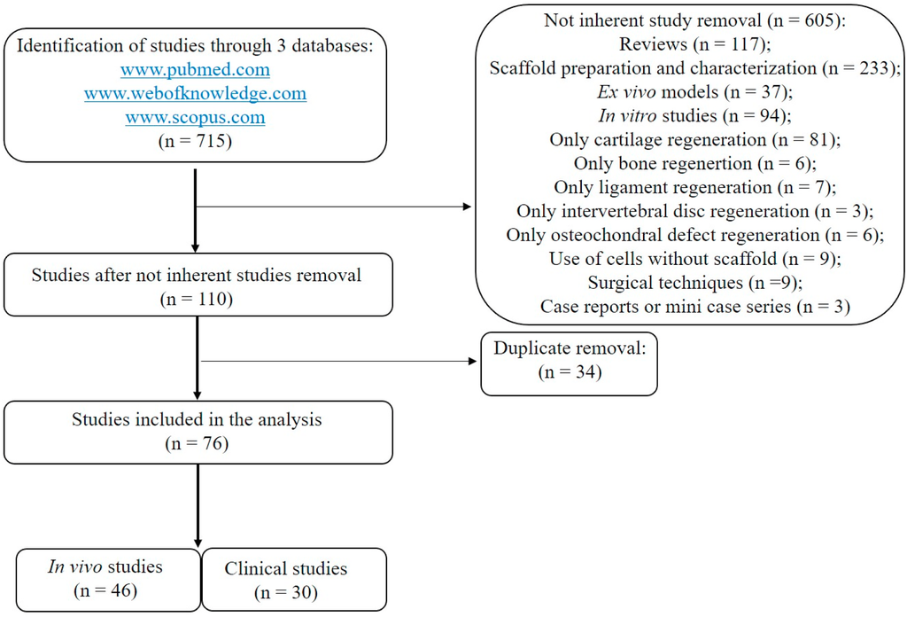

**Fig. 1.** Flowchart of the papers’ selection process.

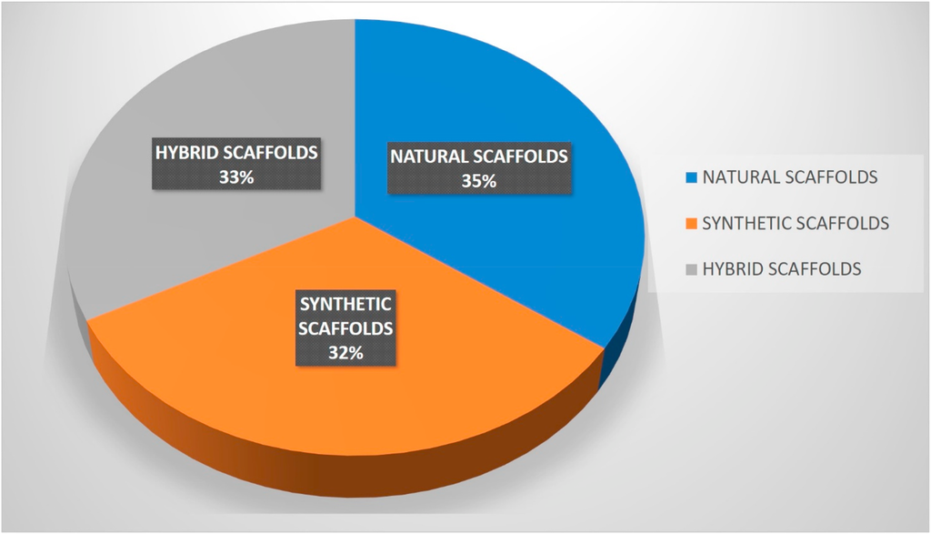

**Fig. 2.** Scaffolds’ use in animal studies.

**Table 1**

Summary of *in vivo* preclinical studies.

Ref.

Animals

CTR

Scaffold

Evaluations

Results:

Study group *Vs* CTR

**Natural scaffolds: cell-free**

Li C et al. *Sci Rep*

2017

15 skeletally

mature Japanese

big-ear rabbits

(3.0–3.5 kg)

Empty

defect

Decellularized autologous ST

6 wks, 3 and 6 mo:

Macroscopy;

Histology;

Histomorphometry;

Biomechanics

↑ covering ratio, Ishida score, Toluidine

blue, COLL I;

↓ COLL III, elastic modulus, hardness

Hansen R et al. *J*

*Orthop Res* 2013

9 skeletally mature

mixed breed dogs

(25.5 kg)

/

CMI

3 and 6 wks, 12, 13,

17 mo:

Histology

Organized and integrated tissue, scaffold

degeneration

Kawaguchi Y et al.

*Orthop Traumatol*

*Surg Res* 2019

75 mature

Japanese White

rabbits (3.8 ± 0.3

kg)

Empty

defect

Autologous meniscal fragments,

decellularized or not

3 and 6 wks, 3 mo:

Macroscopy;

Histology;

Histomorphometry;

Biomechanics

↑ gross evaluation score, cross-sectional

area, histological score, maximal load,

linear stiffness;

Not decellularized scaffold: ↑ histological

score, maximal load, linear stiffness than

decellularized scaffold

Kobayashi Y et al.

*Am J Sports Med*

2010

75 mature

Japanese White

rabbits (3.5 ± 0.2

kg)

Empty

defect

Autologous meniscal fragments

3 and 6 wks, 3 mo:

Macroscopy;

Histology;

Histomorphometry;

Biomechanics

↑ gross and histological score, cross

sectional area, maximal load, linear

stiffness

Gastel JA et al.

*Arthroscopy* 2001

12 NZW rabbits

(3.5–4 kg)

/

SIS

1, 3, 6 mo:

Histology

No incorporation at 1 mo;

More organized and fibrous tissue at 3 mo;

More organized tissue resembling native

meniscus, integration at 6 mo

Cook JL et al. *Am J*

*Sports Med* 2006

51 adult

conditioned dogs

(2–5 yrs,

22.0–34.4 kg)

Empty

defect

SIS

Every mo:

Clinical lameness;

3, 6, 12 mo:

Macroscopy;

Histology;

Ultrasound;

Biomechanics

Animals survived, no surgical

complications.

↓ lameness;

↑ mature appearance, attachment, CSA%,

TSA%, tissue regeneration, organized

tissue, cell density, integration

Gruchenberg K et al.

*Knee Surg Sports*

*Traumatol Arthrosc*

2015

27 skeletally

mature Merino

sheep (4.2 ± 0.9

yrs)

/

Silk fibroin

3, 6 mo:

Macroscopy;

Biomechanics;

Histology

No inflammation, scaffold in place

= Eeq than native meniscus, scaffold not

always fixed

Yuan Z et al.

*Biomaterials* 2016

32 NZW rabbits (3

mo)

Empty

defect

AMECM and/or DCB

3, 6 mo:

Histology;

Histomorphometry;

RT-PCR;

Biomechanics

DCB and AMECM + DCB ↑ regenerated

meniscal tissue than AMECM and empty

defect;

AMECM + DCB ↑ regenerated meniscus

than DCB;

AMECM + DCB ↑ chondrocyte-like cells,

PGs, Col1, Col2, Acan, Sox9, well-

organized collagen, Ishida score, tensile

modulus than AMECM, DCB and empty

defect

Natural scaffolds: cell-free with GFs

Pan Z et al. *Acta*

*Biomaterialia* 2017

20 male NZW

rabbits (5 mo)

Empty

defect

Multi-layer acellular rabbit Achilles

tendon with or without i.a. **gefitinib** (30

mM) injection

2, 4 mo:

Macroscopy;

Histology;

Histomorphometry;

Biochemics

Scaffolds with and without gefitinib ↑

meniscus covering ratio;

Scaffold with gefitinib ↑ Safranin-O, Pauli

score, collagens than empty defect and

scaffold without gefitinib

Natural scaffolds: with cells

Peretti GM et al. *Am*

*J Sports Med* 2004

16 Yorkshire pigs

(3 mo)

Scaffold or

empty

defect

Decellularized allogenic meniscal slides +

autologous chondrocytes

9 wks:

Macroscopy;

Histology;

Histomorphometry

↑ lesion repair, fibro-cartilaginous matrix,

GAGs

Martinek V et al.

*Arch Orthop*

*Trauma Surg* 2006

25 adult Merino

sheep (80.0 ± 10.6

kg)

Scaffold or

empty

defect

CMI + autologous fibrochondrocytes (10

× 10<sup>6</sup>cells/3.25 cm scaffold)

3 mo:

Macroscopy;

Histology

No intra- or post-operative complications,

stable joint.

↑ regeneration, vascularization;

↓ fibrochondrocytes, scar tissue; ↑ matrix,

scaffold remodeling than scaffold

Whitehouse MR

et al. *Stem Cells*

*Transl Med* 2017

30 skeletally

mature sheep (*>*2

yrs)

Scaffold or

empty

defect

Collagen sponge + BMSCs (1 × 10<sup>6</sup>cells/

cm<sup>2</sup>)

13 wks, 6 mo:

Macroscopy;

Histology

↑ meniscus healing at 13 wks;

No healing at 6 mo

Angele P et al. *J*

*Biomed Mater Res*

2008

24 NZW rabbits (5

mo)

Scaffold or

empty

defect

HA/gelatin + autologous BMSCs (10<sup>5</sup>

cells/μl) cultured in CM

3 mo:

Macroscopy;

Histology;

Histomorphometry;

IHC

No infection, chronic inflammation.

↑ integration, fibrocartilage with hyaline

cartilage-like areas, cross-sectional width,

COLL II

Zellner J et al. *J*

*Biomed Mater Res*

*Part A* 2010

60 NZW rabbits (5

mo)

Scaffold or

empty

defect

HA/gelatin + autologous BMSCs (1,5 ×

10<sup>6</sup>cells/scaffold) cultured or not in CM or

BM

6 wks, 3 mo:

Macroscopy;

Histology;

IHC

Scaffold + BM ↑ PG;

Scaffold + BMSCs ↑ PG, moderate COLL II,

integration than scaffold;

(*continued on next page*)

**Table 1** (*continued*)

Ref.

Animals

CTR

Scaffold

Evaluations

Results:

Study group *Vs* CTR

Scaffold + precultured BMSCs ↑fibroblastic

and meniscus-like cells, PG, COLL II

Zellner J et al. *J*

*Biomed Mater Res*

*Part B Appl*

*Biomater* 2013

30 NZW rabbits (5

mo)

Scaffold or

empty

defect

HA/gelatin + autologous BMSCs (1 × 10<sup>6</sup>

cells/scaffold) precultured or not in CM

6 wks, 3 mo:

Macroscopy;

Histology;

Histomorphometry;

IHC;

Biomechanics

Scaffold + BMSCs ↑ healing, scar strength

than scaffold;

Scaffold + precultured BMSCs ↑healing,

matrix, COLL II, scar strength than scaffold

Natural scaffolds: with cells and GFs

Koh RH et al. *Acta*

*Biomaterialia* 2017

6 NZW rabbits

(3–3.3 kg)

Scaffold or

medium

with TGF-β3

COL-RF-HA + human T-MSCs (1 × 10<sup>6</sup>

cells/construct) cultured with conditioned

medium from meniscal fibrochondrocytes,

cultured with **TGF-****β****3**

10 wks:

Histology;

IHP;

Histomorphometry

↑ cellularity, PGs, GAGs, collagens, COLL II

Synthetic scaffolds: cell-free

Zhang ZZ et al. *Acta*

*Biomaterialia* 2016

24 NZW rabbits (3

mo)

Empty

defect

PCL (pore of 215, 320 or 515 μm)

3 mo:

Macroscopy;

Histology;

IHC

No complications, weight change,

inflammation.

↑ macroscopical aspect;

Scaffold (pore of 215 μm) ↑ macroscopical

aspect, COLL I, COLL II than scaffolds (pore

of 320, 515 μm)

Otsuki S et al. *Am J*

*Sports Med* 2019

16 minipigs (42.6

mo, 51.6 kg)

Empty

defect

PGA coated with PLLA/PCL sponge

1, 2, 6 mo:

Macroscopy;

Histology;

IHC

↑ meniscus size, Ishida score, collagen

structure, COLL I, COLL II; ↓ Pauli score

Testa Pezzin AP

et al. *Artif Org*

2003

34 adult NZW

rabbits (5–7 mo,

2–4 kg)

/

PLLA/PPD

3, 6, 12, 14 wks:

Histology

Degradation at 6 wks and tissue

infiltration;

Fibrocartilage at 12 wks;

Aligned fibers at 14 wks

Tienen TG et al.

*Biomaterials* 2003

12 adult Beagles

(13.1 ± 1.6 Kg)

Empty

defect

PUEs based on PLLA/PCL

3, 6 mo:

Histology;

IHC;

Macroscopy;

Histomorphometry

Normal gait, no infections.

↑ intact menisci, COLL II; chondrocyte-like

cells, COLL II and PGs, almost complete

integration, starting of scaffold

degradation, macrophages, giant cells, no

inflammation

Galley NK et al. *Clin*

*Orthop Relat Res*

2011

13 healthy,

skeletally mature

Columbia X

Rambouillet sheep

/

Actifit®

3, 6, 12 mo:

Histology;

Biomechanics

tissue infiltration, stained matrix; ↓

compressive modulus; = permeability than

native meniscus

Maher SA et al.

*Arthroscopy* 2010

42 skeletally

mature Columbia X

Rambouillet ewes

Empty

defect

Actifit®

3, 6, 12 mo:

Macroscopy;

Histology

Normal gait. regenerated and dense tissue

filling the defect, cell infiltration, matrix

deposition, PGs, collagen

Welsing RTC et al.

*Am J Sports Med*

2008

13 adult Beagle

dogs (12.5 ± 0.2

Kg)

Empty

defect

PCL-PU

6, 24 mo:

Histology;

Histomorphometry;

IHC

Well connected, cartilage-like tissue with

chondrocyte-like cells, COLL I, COLL II,

collagen filled the pores, no inflammation,

polymer fragments

= compression-stress curves than native

meniscus at 6 mo

Heijkants RGJC

et al. *J Mater Sci*

*Mater Med* 2004

12 adult Beagles

(13.1 ± 1.6 Kg)

Empty

defect

PCL-PU

6 mo:

Biomechanics;

Histology;

IHC

No infections.

Tissue infiltration;

= compression curve, PG, COLL I, COLL II

than native meniscus

Synthetic scaffolds: with cells

Zhang ZZ et al. *Am J*

*Sports Med* 2017

72 skeletally

mature NZW

rabbits (3.0 kg)

Scaffold or

empty

defect

PCL + allogenic BMSCs (5 × 10<sup>6</sup>cells/

scaffold)

3, 6 mo:

Macroscopy;

Histology;

IHC;

Biomechanics

No weight changes, complications.

↑ scaffold integration, shape, total

macroscopic score, COLL I, COLL II, tensile

modulus, aggregate modulus, ultimate

tensile strength, GAGs

Gu Y et al. *Exp Ther*

*Med* 2012

24 Beagle dogs (6

mo)

Scaffold or

empty

defect

PLGA + chondrogenically induced

myoblasts (1.5 × 10<sup>7</sup>/0.3 ml)

3 mo:

Macroscopy;

Histology;

IHC;

Histomorphometry

↑ defect filling, Th, integration, meniscus-

like fibrocartilage with hyaline cartilage-

like areas, COLL II;

Scaffold ↑ Th than empty defect

Weinand C et al.

*Arch Orthop*

*Trauma Surg* 2006

15 swines

Scaffold or

empty

defect

Woven PLGA mesh + chondrocytes (1 ×

10<sup>6</sup>cells/ml)

3 mo:

Macroscopy;

Histology

Well ambulation, no infections, no

swelling, no redness.

Closed lesion, complete healing, fibrous

tissue, some histiocytes

Weinand C et al. *Am*

*J Sports Med* 2006

28 swines

Scaffold or

empty

defect

Woven PLGA mesh + autologous or

allogenic chondrocytes (1 × 10<sup>6</sup>cells/ml)

3 mo:

Macroscopy;

Histology;

Histomorphometry

No swelling.

Partial of full closure of lesion, new scar-

like tissue, few histiocytes, ↑ healed lesion

%,;

Scaffold or empty defect no closure, no

healing

Koch M et al. *Stem*

*Cell Int* 2018

14 NZW rabbits

(12–14 wks,

2.8–3.2 kg)

Scaffold

Actifit®+BMSC suspension (200 μl, 2 ×

10<sup>4</sup>nucleated cells/μl)

6 wks, 3 mo:

Macroscopy;

↑ meniscus score, integration, healing, PGs

(*continued on next page*)

**Table 1** (*continued*)

Ref.

Animals

CTR

Scaffold

Evaluations

Results:

Study group *Vs* CTR

Histology;

IHC

Kang SW et al. *J*

*Biomed Mater Res*

2006

9 NZW rabbits (6

wks, 3.5 ± 0.4 kg)

Scaffold

PGA/PLGA + allogenic meniscal

chondrocytes (2 × 10<sup>6</sup>cells/scaffold)

6, 10 wks, 9 mo:

Histology;

IHC;

Water content and

total collagen content;

Cytoindentation

Meniscus tissue formation with original

scaffold shape, slightly larger than the

original scaffold, structure similar to native

meniscus, fibrocartilage,

fibrochondrocytes, collagens, organized

structure, PGs, COLL I, COLL II, water

content, Young’s modulus similar to native

meniscus.

Scaffold no maintenance of the shape and

size of the original scaffold

Esposito AR et al.

*Biores Open Access*

2013

24 NZW rabbits (5

mo)

Scaffold or

empty

defect

PLDLA/PCL-T + fibrochondrocytes

12, 24 wks:

Macroscopy;

Histology

↑ Fibrocartilaginous tissue

Scaffold + fibrochondrocytes and scaffold

complete healing of the incision, with no

external scar, tissue with features similar to

those of native meniscus

Hybrid Natural/Synthetic scaffolds: cell-free

Gao S et al. *Acta*

*Biomater* 2018

20 NZW rabbits (3

kg)

Empty

defect

DMECM sponge + DMECM/PCL fiber films

3, 6 mo:

Macroscopy;

Histology;

IHC;

Biomechanics;

Biochemics

↑ meniscus-like cells, meniscus covering

area, regeneration, GAGs, COLL I, COLL II,

Ishida score

Ghodbane SA et al.

*Tissue Eng Part A*

2019

24 skeletally

mature Dorset Finn

Cross Sheep (2–3

yrs)

Empty

defect

COLL reinforced with polymer fiber

(pDTDDD)

3, 6 mo:

Histology;

Histomorphometry;

IHP;

Biochemics

normal cell morphology; ↑ vascularization,

collagenous bundles, COLL I, GAGs,

Collagen; ↓ lymphocytes and

multinucleated giant cells

Merriam AR et al.

*Am J Sports Med*

2015

20sheep

Empty

defect

COLL reinforced with polymer fiber

(pDTDDD)

4, 8 mo:

Biomechanics;

Histology;

IHP

Neomeniscus tissue, no scaffold, organized

tissue, COLL I, COLL II; ↓ multinucleated

giant cells, inflammatory cells

Patel JM et al. *Am J*

*Sports Med* 2016

10 skeletally

mature Dorset Finn

Cross sheep (2–3

yrs)

Empty

defect

COLL reinforced with polymer fiber

(pDTDDD)

13 mo:

Biomechanics;

Histology;

IHC;

Biochemics

↑ cell infiltration, areas of dense ECM

deposition with aligned collagen fibers,

blood vessels, COLL I, COLL II; ↓

inflammatory cells

Patel JM et al. *Am J*

*Sports Med* 2018

12 skeletally

mature Dorset Finn

cross sheep (2–3

yrs)

/

COLL reinforced with polymer fiber

(pDTDDD)

24 mo:

Macroscopy;

Histology;

IHC;

Biomechanics

↓ coverage%, Eeq, Ultimate tensile load,

tensile stiffness than native meniscus;

Dense tissue deposition and organization,

no inflammation, vascular ingrowth,

bundles of collagen, no calcification,

chondrocyte-like cells, COLL I, COLL II

Patel JM et al. *Tissue*

*Eng Part A* 2016

9 skeletally mature

Dorset Finn cross

sheep (2–3 yrs)

/

COLL–HA reinforced with PLLA fibers

2, 4, 6, 8 mo:

Biomechanics;

Histology;

Biochemics

↓ Aggregate modulus; = collagen, GAGs

than native meniscus;

Polymer fibers observed, cell infiltration,

new collagen deposition and organization

at 4 mo, reduced during time, areas of

aligned ECM; ↓ macrophages

Chiari C et al.

*Osteoarthritis*

*Cartilage* 2006

8 skeletally mature

Austrian stone

sheep (50–64 kg)

Total MMx

or PMx

empty

defect

HA/PCL

6 wks:

Histology

No degeneration, stable joints.

Total MMx or PMx with or without scaffold

excellent bonding between the implant and

the capsule, tissue formation, vessels, giant

cells;

PMx with or without scaffold fibrous tissue

Cojocaru DG et al. *J*

*Biomed Mater Res*

2020

12sheep

Empty

defect

3D meniscus-shaped PGA-HA

6 mo:

Histology;

IHC;

Histomorphometry

No inflammation. repair tissue rich in PGs

and COLL I, not completely covering the

whole defect area

Demirkiran ND et al.

*Acta Orthop*

*Traumatol Turc*

2019

16 adult NZW

rabbits (12 mo)

Empty

defect

Multilayer meniscal scaffold or Actifit®

2 mo:

Macroscopy;

Histology;

Biomechanics

No animals died, no redness, swelling, heat,

disruption or abscess, inflammation.

Multilayer meniscal scaffold ↑ maniscus

areas, Th defect area, Hayes scores,

compression tests than empty defect

Shimomura K et al.

*Biomaterials* 2019

18 skeletally

mature NZW

rabbits (3.3–4.0 kg)

Scaffold or

empty

defect

Electrospun nanofibrous PCL/PEO

scaffold + TEC

1, 2, 3 mo:

Histology;

IHC;

Biomechanics

No inflammation or immunological

rejection.

↑ GAGs, COLL II, cross-sectional areas

Hybrid Natural/Synthetic scaffolds: cell-free with GFs

Nakagawa Y et al.

*Am J Sports Med*

2019

34 skeletally

mature sheep (2.4

yrs, 55.3 kg)

Scaffold

GF–laden PCL + **CTGF** (5 or 10 μg)+**TGF-**

**b3** (5 or 10 μg)

6, 12 mo:

MRI;

Macroscopy;

Histology;

Histomorphometry

↑ regenerated tissue, fibrous tissue;

Scaffold + CTGF (5 μg)+TGF-β3 (5 μg) ↑

matrix organization, PG, fibrocartilage; ↓

MRI score than scaffold + CTGF (10 μg)+

TGF-β3 (10 μg) and scaffold;

(*continued on next page*)

scaffold, loaded with tonsillar MSCs (T-MSCs) and cultured in condi-

tioned medium of meniscal fibrochondrocytes, previously cultured with

TGF-β3 [36].

• One biomaterial:

1) Decellularized allogenic meniscus slides increased lesion repair,

GAGs, fibro-cartilage matrix formation [30];

2) CMI, that regenerated a tissue with higher vascularization, matrix

remodeling and lower scar formation [31];

3) Collagen type I sponge significantly increased meniscus healing,

but, after 6 months, no healing was observed [32].

• More biomaterials:

1) HA/gelatin scaffold with autologous BMSCs, induced the regen-

eration of a tissue with higher integration, fibrocartilage aspect

with hyaline-cartilage areas, PGs, cross-sectional area and COLL II

in comparison to scaffold alone [33,34], but when loaded with

BM *in toto*, only PG increased in the regenerated tissue [34].

However, the major effects were observed when scaffold was

loaded with BMSCs, pre-cultured in chondrogenic medium,

showing the highest tissue healing and strength, fibroblasts,

meniscus-like cells, PGs and COLL II [34,35];

2) the COL-RF-HA scaffold, which was cultured in conditioned me-

dium from meniscal fibro-chondrocytes, previously expanded in

presence of TGF-β3. It induced the formation of a new tissue with

higher cellularity, collagens, PG and GAGs in comparison to

scaffold cultured in medium containing TGFβ3 or acellular scaf-

fold [36].

*3.1.2. Synthetic scaffolds*

*3.1.2.1. Cell-free scaffolds.* One synthetic scaffold was composed by one

component: Polycaprolactone (PCL) [37]. Other scaffolds were

composed by polyglycolic-Acid (PGA) felt layer coated with a PLLA/PCL

(50:50) sponge [38], poly(p-dioxanone) (PPD)/PLLA [39], polyester

urethanes (PUEs) based on PLLA/PCL [40], porous aliphatic poly-

urethane (PU) and PCL (Actifit®) [41,42], or PCL-PU [43,44].

• One biomaterial:

1) PCL alone didn’t increase complications or inflammation and the

macroscopic appearance of new regenerated tissue improved in

comparison to empty defects. Best results were obtained with

pore size of 215 μm than with the other two types of pore sizes,

320 and 515 μm [37].

• More biomaterials:

1) PGA coated with PLLA/PCL sponge significantly increased

meniscus size, collagens and structure than empty defect. An in-

crease in PCNA-positive cells and TNFα was observed only at 2

months, disappearing at 6 months [38];

2) PUEs based on PLLA/PCL scaffold increased the formation of

intact menisci with COLL II, chondrocyte-like cells, PGs, and

initial scaffold degradation was also observed [40];

3) PPD/PLLA blend degraded, generating fibro-cartilaginous tissue

and aligned fibers [39];

4) Actifit® significantly increased matrix formation, cell infiltration,

matrix deposition, PGs and collagens, but with reduced

compressive modulus than native meniscus, maintaining the

same permeability [41,42];

5) the combined PCL-PU scaffold showed a good integration, with a

formation of a cartilage-like tissue, chondrocyte-like cells, high

COLL I and COLL II, no inflammation and similar compression

curve, PGs, COLL I, COLL II content than native meniscus [43,44].

cells were: PCL [45]; Poly(lactide-co-glycolide) (PLGA) (90/10)

[46–48]. They were seeded with autologous BMSCs [45], chon-

drogenically induced myoblasts [46] or chondrocytes [47,48].

The scaffolds composed by more biomaterials and seeded with cells

were instead: Actifit® [49]; PGA/PLGA [50]; and poly(L-co-D,L-lactic

acid) (PLDLA)/poly(caprolactone-triol) (PCL-T) (70/30) [51]. These

were seeded with BMSCs [45], chondrocytes [50] or fibro-chondrocytes

[51].

• One biomaterial:

**Table 1** (*continued*)

Ref.

Animals

CTR

Scaffold

Evaluations

Results:

Study group *Vs* CTR

Scaffold + CTGF (10 μg)+TGF-β3 (10 μg) ↑

PG than scaffold

Hybrid Natural/Synthetic scaffolds: with cells

Moradi L et al.

*Biomaterials* 2017

29 NZW rabbits (5

mo)

Scaffold

PVA/Ch cross-linked by PPU chains +

autologous chondrocytes and/or allogenic

ADSCs (5 × 10<sup>4</sup>cells/cm<sup>2</sup>)

7 mo:

Macroscopy;

Histology;

IHP

No infection, no chronic inflammation.

Scaffold + chondrocytes or chondrocytes

and ADSCs ↑ regenerated tissue, GAGs,

parallel COLL I and COLL II fibers than

scaffold or scaffold + ADSCs

Kon E et al. *Tissue*

*Eng Part A* 2008

26 skeletally

mature adult sheep

(3.1 ± 1.8 yrs)

Scaffold or

empty

defect

HA/PCL with transtibial fixation of the

horns or sutured to the capsule and

meniscal ligament and transtibial fixation

of the horns + autologous chondrocytes

(25 × 10<sup>6</sup>cells/cm<sup>3</sup>)

17 wks:

Macroscopy;

Histology

All animals tolerated surgery well and

survived, normal gait. All joints stable.

Residual scaffold, giant cells, mononuclear

histiocytes, vascularization, cellular tissue,

few lymphocytes and plasma cells;

↑ small foci of cartilage areas

Kon E et al. *Tissue*

*Eng Part A* 2012

18 skeletally

mature adult

Bergamasca–

Massese sheep (70

± 5 kg)

Scaffold or

empty

defect

HA/PCL + autologous chondrocytes (25 ×

10<sup>6</sup>cells/cm3)

12 mo:

Macroscopy;

Histology

All animals tolerated surgery well and

survived, normal gait.

↑ macroscopic score, cartilage metaplasia;

↓ fibrosis than scaffold;

Scaffold and scaffold + chondrocytes

scaffold residuals, foreign body reaction,

well-organization and tight integration,

vessels, inflammatory response than empty

defect

Hybrid Natural/Synthetic scaffolds: with cells and GFs

Chen C et al. *Am J*

*Sports Med* 2020

30 mature NZW

rabbits (16–18 wks;

2.5–3.0 kg)

Scaffold or

empty

defect

GC/4-Arm

PEG-CHO Hydrogel + autologous BMSCs

(2 × 10<sup>7</sup>cells/ml)+**TGF****β** (1 mg/ml)

2 mo:

Macroscopy;

Hystology;

Histomorphometry;

IHC

Standard C-shape, defect region invisible; ↑

GAGs, Ishida score, COLL II; ↓ COLL I than

scaffold + BMSCs and empty defect;

Caffold + BMSCs ↑ Ishida score than empty

defect

1) PCL scaffolds significantly increased tissue integration, GAGs,

COLL I, COLL II and biomechanics (tensile modulus, aggregate

modulus, ultimate tensile strength) [45];

2) non-woven PLGA scaffold induced a higher defect filling, scaffold

integration, meniscus-like fibrocartilage formation and COLL II

and tissue thickness in comparison to unseeded scaffold or empty

defects [46]. The woven PLGA meshes closed the lesion, inducing

a complete healing with fibrous tissue and some histiocytes.

However, scaffold without cells was not able to regenerate new

tissue. No differences were observed between autologous or

allogenic cells [47,48].

• More biomaterials:

1) Actifit® significantly increased meniscus regeneration, integra-

tion, healing, PG content [49];

2) PGA/PLGA induced the formation of a meniscus-like tissue within

the original scaffold shape, slightly larger than the original scaf-

fold and with structure, fibrocartilage, fibrochondrocytes, colla-

gens, PGs, COLL I, COLL II, water content, and Young’s modulus

similar to native meniscus [50];

3) PLDLA/PCL-T induced a complete tissue healing, with no scar

tissue, and features similar to the native meniscus [51].

*3.1.3. Hybrid natural-synthetic scaffolds*

*3.1.3.1. Cell-free scaffolds.* The following cell-free scaffolds were

investigated: decellularized meniscus extracellular matrix (DMECM)

sponge and DMECM/PCL fiber [52]; Type I bovine Achilles tendon

collagen sponge reinforced with p(DTDDD) fibers [53–56]; COLL–HA

reinforced with PLLA fibers [57]; PCL/HA (70/30), augmented with PLA

fibers or PET nets [58]; PGA/HA [59]; multi layered scaffold, composed

by PHBV, HA and strontium ranelate, and durable cellulose fibers from

Luffa cylindrical [60]; PCL (MW = 80 kDa) and PEO (50/50) electrospun

nanofibrous and TEC [61]; PCL (MW = 65000) in which TGFβ3 and

CTGF were encapsulated in PLGA μS [62].

1) The first scaffold of the aforementioned list induced the formation of

a meniscus tissue with higher meniscus-like cells, covering area,

regeneration, GAGs, COLL I and COLL II than empty defects. In

addition, the regenerated tissue showed water, collagen and GAG

content similar to native meniscus, but with lower tensile modulus

[52];

2) COLL reinforced with p(DTDDD) fibers, regenerated a tissue with

better cell morphology, higher GAGs, vascularization, collagenous

bundles, chondrocyte-like cells and no calcification and lower lym-

phocytes and multinucleated giant cells than empty defects [53–56].

The biomechanical features (Aggregate modulus, Ultimate tensile

load, Tensile stiffness and Eeq) of the regenerated tissue were infe-

rior, while permeability was higher than native meniscus [54–56].

Collagen and GAG content were similar to native meniscus [56];

3) COLL-HA reinforced with PLLA fibers induced the regeneration of a

tissue with lower aggregate modulus, but similar collagen and GAG

than native meniscus; scaffold fibers were always present, with

concomitant cell infiltration, new collagen deposition and organized

areas of aligned ECM and macrophages [57];

4) PCL mixed with HA increased tissue formation and vascularization

[58];

5) PGA/HA scaffold regenerated a tissue rich in PGs and COLL I [59];

6) The multi-layered scaffold composed of PHBV, HA, strontium rane-

late and durable cellulose fibers increased meniscus areas, tissue

thickness and presented also better compression tests in comparison

to empty defect [60];

7) PCL/PEO scaffold, combined with TEC, increased GAG, COLL II and

cross-sectional areas more than scaffold alone or empty defect [61];

8) PCL mixed with HA scaffold was loaded with two GFs (TGFβ3 and

CTGF), showing higher meniscus regeneration with higher matrix

and PG when GFs were loaded at a concentration of 5 μg rather than

10 μg [62].

*3.1.3.2. Scaffolds with cells.* PVA/Ch cross-linked with PPU (PVA/Ch/

PPU 1:4:1) [63]; HA/PCL (70/30) [*64, 65*]; and GC/4-Arm PEG-CHO

hydrogel (1:1) [*66*] scaffolds were implanted with: chondrocytes and/or

ADSCs [63], chondrocytes alone [*64, 65*] or BMSCs [*66*]. Here follows a

more detailed description of the outcomes of each of the aforementioned

scaffolds:

1) PVA/Ch/PPU scaffold, seeded with autologous chondrocytes alone

or chondrocytes and allogenic ADSCs, significantly induced the for-

mation of a regenerated meniscus similar to the native one, con-

taining higher GAGs, COLL I and COLL II than scaffold alone or

scaffold seeded with ADSCs [63];

2) HA/PCL significantly increased macroscopic score, cartilage meta-

plasia and significantly reduced fibrosis than scaffold alone [64] and,

when the scaffold was fixed with two sutures, increased giant cells,

mononuclear histiocytes, vascularization, and cellularized tissue

were seen [65];

3) GC/4-Arm PEG-CHO hydrogel created a standard C-shaped tissue

with higher GAGs and COLL II when seeded with autologous BMSCs,

cultured with the GF TGFβ, in comparison to the scaffold cultured in

growth medium or empty defects [66].

*3.2. Clinical results*

*3.2.1. CMI scaffold*

The analysis of the available literature yielded 10 trials, all pro-

spective, that included 593 patients in total [67–76] (Fig. 3). A detailed

synopsis of the main features of the included studies is available in

Table 2.

The quality of methodology, assessed by the modified Coleman

score, revealed overall modest results, with scores ranging from 34 [69]

to 63 [67,71]. Only one randomized controlled trial is currently avail-

able [74]. Looking at the clinical results, all the trials revealed positive

findings in terms of pain reduction and increase in subjective functional

scores. Few studies documented stability of results up to a long-term

evaluation (in the range of 8–10 years’ follow-up) [67,75,76]. Any-

way, these encouraging findings should be carefully weighed against the

high number of concomitant procedures performed in most of the trials

(Table 3), which represents a confounding bias in the assessment of the

CMI scaffold contribution to the final outcome. To this regard, only one

trial reported results of isolated CMI implantation in a small cohort of

patients evaluated up to 8 years’ follow-up [75].

Interestingly, the only randomized trial published [74] revealed that

CMI implantation is able to provide more symptomatic relief and restore

better knee function compared to meniscectomy alone at mid-term fol-

low-up. Second look arthroscopies documented new tissue regrowth

within the scaffold and also histology showed formation of

fibro-chondrocyte matrix.

Similar results were found in a controlled study by Zaffagnini et al.

[67], who investigated the difference among patients who received

meniscectomy alone and those treated by meniscectomy and concurrent

CMI implantation: the latter presented lower pain and higher IKDC subj.

score at follow-up and also less progression to OA compared to menis-

cectomized patients, thus supporting the chondroprotective role of the

collagen scaffold.

Another study investigated the different outcomes of patients

receiving ACL reconstruction and concurrent medial meniscectomy or

CMI implantation [69]: even in this case, the scaffold group showed less

pain and better arthrometric parameters, thus confirming that meniscal

tissue preservation significantly contributes to knee stability.

With regard to MRI evaluations, the most adopted method was the

Genovese score: overall, the MRI appearance of the CMI scaffold evolved

positively over time, with just a very few cases of complete resorption of

the scaffold. Anyway, complete healing and restoration of normal

“meniscus-like” tissue occurred in a limited percentage of patients,

whereas the majority of them still showed different intensity of signal at

the site of CMI implantation, smaller overall size of the treated meniscus

and a certain amount of extrusion [67,70,74,76].

*3.2.2. ACTIFIT**®* *scaffold*

Nineteen studies analyzed the potential of Actifit® as a synthetic

meniscal substitute, for a total of 777 patients treated [77–95] (Fig. 3). A

detailed synopsis of the included trials is available in Table 2. Almost all

these investigations (16 out of 19) have been prospectively performed

[77–85,87–93] and only 3 retrospective studies [86,94,95] were found.

Four studies reported on a multi-centric clinical examination [77,89,90,

93].

All studies described positive clinical outcomes following Actifit®

implantation. Significant relief of pain was found. Clinical improve-

ments in the operated knee have also been documented by different

clinical scales (IKDC objective and subjective score, KOOS score,

Lysholm scale, Cincinnati rating system, KSS, Tegner scale, WOMET,

Kujala, UCLA scale).

No major implant-related adverse events (AEs) and complications

have been reported, as described in 3 different clinical examinations

wound infections [83], 4 revision surgery for persisting symptoms

(including 1 unicondylar knee arthroplasty after 6 months) [85,90], 2

post-operative infections [89,90], 1 progression of cartilage damage

[89], 1 residual pain for saphenous nerve injury [91], 1 quadriceps

weakness for femoral nerve damage related to anesthesia [91], 5 joint

stiffness [90,91].

Radiological outcomes of Actifit® have been described in 15 papers

which adopted MRI to assess different size, reabsorption, hyperintensity

and extrusion of the meniscal substitute [78–82,84–89,91–94].

Nine studies employed the Genovese scale for the MRI assessment,

resulting, in the majority of cases, in “type II” scaffolds (i.e. smaller and

with a hyperintense signal at MRI compared to a normal meniscus) [79,

82,84–86,88,92–94]. Complete resorption of the scaffold was a rare

event in the available literature, whereas reduction in size relative to

native meniscus, slightly or marked hyperintensity and implant extru-

sion have been revealed as common findings in the majority of MRI

examinations. The main issue in the evaluation of Actifit® implant is the

massive presence of patients who underwent associated surgeries, such

as osteotomies and concurrent cartilage treatments (Table 3), that might

have biased the interpretation of data.

Only 4 trials included patients treated only by Actifit® implantation

[80,87,88,94]. Considering that two of them [87,88] examined the same

population at different follow-up times, the total number of patients that

can provide for unbiased data about the polyurethane meniscal scaffold

is 51.

The first study [80] included 10 patients evaluated at 6 and 12

months: KOOS and KSS scales were significant better at both follow-ups

and MRI exams described stable, non-reabsorbed and non-hyperintense

scaffolds.

The study by Akkaya M et al. [94] confirmed good clinical results

with significantly better scores in Lysholm, KOOS, IKDC and lower pain

at 36 months. At the same follow-up time, slight scaffold extrusion was

observed with a mean value of 2.4 mm. Cartilage status was assessed

through Outerbridge grading scale and no difference was found between

baseline and 36 months’ follow-up.

In the other two studies, Schuttler KF et al. [87,88] revealed signif-

icant improvements in KOOS, KSS, UCLA scale and VAS at 6, 12, 24 and

48 months from surgery. No scaffold extrusion and reabsorption were

observed at MRI. Similar findings were reported also by Condello et al.

[95], who also documented that delayed Actifit® implantation (i.e.

more than 6 months after meniscectomy) leads to inferior clinical

outcomes.

*3.2.3. CMI vs Actifit**®*

Only one prospective, non-randomized trial [96] compared the

outcomes of CMI and Actifit® scaffolds. Fifty-three patients in total were

included and evaluated up to 24 months: no significant difference was

detected in any clinical scores considered. A similar rate of complica-

tions was observed between the two groups. Biopsies performed during

second look arthroscopies revealed different histologic findings: the CMI

was mainly replaced by fibrous tissue, whereas in the case of the Actifit®

an avascular cartilaginous-like tissue was present. In all cases, the

scaffolds were still visible at macroscopic and microscopic level, thus

suggesting an incomplete meniscal healing process after two years from

implantation.

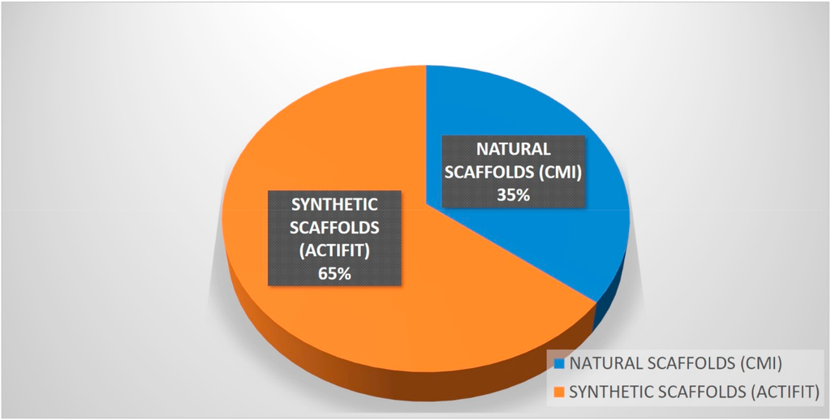

**Fig. 3.** Scaffolds’ use in clinical studies.

**Table 2**

Summary of clinical studies (MM=medial meniscus; LM= lateral meniscus; MRI= magnetic resonance imaging; mo=months).

Ref.

COLEMAN

SCORE

PZ

INCLUSION CRITERIA

SCAFFOLD

EVALUATIONS

RESULTS

Zaffagnini S et al.

*Am J Sports Med*

2011 [67]

63

Prospective

controlled study: 36

pz (40 yrs, 24–60 yrs).

A) Scaffold (18 pz);

B) No Scaffold (18 pz)

Irreparable acute meniscal

tears requiring partial MMx or

chronic prior loss of MM *>* 25%

CMI

3, 6, 12, 24, 60, 120 mo:

VAS, IKDC, Lysholm score,

Tegner scale;

SF-36;

MRI

Group A): ↓ VAS; ↑ IKDC, Tegner

scale, SF-36, than group B) at 120

mo.

Group A): myxoid degeneration

signal in 11 pz

Zaffagnini S et al.

*Am J Sports Med*

2012 [68]

55

Case series: 25 pz

(36.3 ± 11.5 yrs,

16.2–53.4 yrs)

Irreparable acute LM tears

requiring partial LMx or prior

loss of LM *>* 25%

CMI

6, 24 mo: subjective

Lysholm score, VAS,

Tegner scale, IKDC; EQ-

5D;

MRI (Genovese score)

No complications.

6, 24 mo: ↑ Lysholm score, IKDC; ↓

VAS than presurgery.

24 mo: ↑ Tegner activity level, EQ-

5D than presurgery and 6 mo.

Scaffold with identical shape and

size than native meniscus in 3 pz,

smaller in 18 pz, totally reasorbed

in 3 pz, full maturation in 37.5%

cases

Bulgheroni E et al.

*Knee Surg Sports*

*Traumatol*

*Arthrosc* 2015

[69]

34

Comparative trial: 34

pz (33.6 yrs).

A) Scaffold (17 pz);

B) No scaffold (17 pz)

Partial MMx or chronic prior

loss of MM *>* 25%, intact

anterior and posterior meniscus

attachments, intact rim (≥1

mm)

CMI

9.6 ± 2.5 yrs:

Lysholm score, Tegner

Scale, IKDC;

EQ-5D;

VAS

Groups A), B): ↑ Lysholm score,

Tegner scale, IKDC than

presurgery.

Group B): ↓ VAS than presurgery

Schenk L et al.

*Knee Surg Sports*

*Traumatol*

*Arthrosc* 2020

[70]

61

Prospective study: 39

pz (34 ± 10 yrs)

CMI performed due to

prophylactic (n = 25) or

therapeutic indication (n = 14)

after subtotal meniscectomy

CMI

36–84 mo:

VAS, Tegner Scale,

Lysholm score, IKDC

↓ VAS, IKDC; ↑ Tegner scale,

Lysholm score.

Meniscus implant resorbed in 21%

of patients and partially resorbed

in 79% of patients. Meniscus graft

isointense in 21% of patients,

slightly hypertense in 74% of

patients and highly hyperintense in

5%.

Zaffagnini S et al.

*Arthroscopy*

2015 [71]

63

Prospective, single-

arm, multicenter

study: 43 pz (30.1 ±

12.0 yrs)

Irreparable, acute lateral

meniscal lesion requiring

partial meniscectomy or

degenerative loss of lateral

meniscal tissue greater than

25%

CMI

6, 12, 24 mo:

Lysholm score, VAS

(strenuous activity,

routine and at rest), Tegner

activity scale, functional

evaluation and

satisfactional

questionnaire

↓ VAS; ↑ Lysholm score, Tegner

scale

Hirschmann MT

et al. *Knee Surg*

*Sports Traumatol*

*Arthrosc* 2013

[72]

60

Prospective study: 67

pz (36 ± 10 yrs)

Subtotal medial or lateral

meniscectomy

CMI

12 mo:

IKDC, Tegner scale,

Lysholm score, VAS and

satisfactional

questionnaire

↓ Tegner scale, VAS; ↑ Lysholm

score, IKDC

Bulgheroni P et al.

*Knee* 2010 [73]

62

Prospective study: 34

pz (Mean 39 yrs)

Irreparable medial meniscus

tears with meniscus removal

greater than 25% of total

meniscus or presence of

persistent pain after

meniscectomy

CMI

24, 60 mo:

Lysholm score, Tegner

scale, MR arthrography

↑ MR, Lysholm score, Tegner scale

Rodkey WG et al. *J*

*Bone Joint Surg*

*Am* 2008 [74]

58

Prospective

randomized study,

two study arms: 311

pz

A) no previous

surgery (157 pz;

mean age 40 yy);

B) previous surgery

(154 pz; mean age 39

yy)

Irreparable injury of the medial

meniscus or a previous partial

medial meniscectomy

CMI

59 mo mean (16–92):

Lysholm score, Tegner

scale, VAS, second-look

arthroscopy, biopsy and

histological evaluation,

patient self assestment

Groups A), B): ↑ Tegner scale,

Lysholm score. VAS and self

assessment not significantly

different.

At second-look arthroscopy ↑ total

tissue surface area

Zaffagnini S et al.

*Knee Surg Sports*

*Traumatol*

*Arthrosc* 2007

[75]

57

Prospective study: 8

pz (Mean 25 yrs)

Irreparable meniscal tear or a

previous meniscectomy

involving the medial meniscus

CMI

3, 6, 12, 24, and from 72 to

96 mo:

X-ray, MRI, CKRS, IKDC,

VAS, subjective

evaluation, second look

artroscopy

↓ VAS, CKRS, IKDC.

At second look arthroscopy

presence of new tissue in some

cases

Kovacs BK et al.

*Knee Surg Sports*

*Traumatol*

*Arthrosc* 2019

[76]

54

Prospective study: 57

pz (43.6 ± 11 yrs)

Meniscectomy involving

medial or lateral meniscus

CMI

12, 24, and 36–96 mo:

VAS, Lysholm score, MRI,

CMI morphology

↓ VAS; ↑ Lysholm score.

Abnormal and inhomogeneous

signal intensity and irregular

margins of the CMI which tend to

decrease over time

Bouyarmane H

et al. *Orthop*

*Traumatol Surg*

*Res* 2014 [77]

48

Prospective, single-

arm, multicentric

study: 54 pz (16–50

yrs)

Postmeniscectomy syndrome:

painful LM tear or partial

lateral meniscectomy (32–60

mm)

Actifit®

6, 12, 24 mo:

VAS, IKDC, KOOS

↓ VAS; ↑ IKDC, KOOS than

presurgery.

24 mo: ↓ VAS than 12 mo

(*continued on next page*)

**Table 2** (*continued*)

Ref.

COLEMAN

SCORE

PZ

INCLUSION CRITERIA

SCAFFOLD

EVALUATIONS

RESULTS

De Conick T et al.

*Am J Sports Med*

2013 [78]

51

Prospective case-

series study: 26 pz

(17–50 yrs)

Irreparable symptomatic

meniscal tear or partial

meniscectomy (8 LM, 18 MM)

Actifit®

3, 12, 24 mo:

KOOS, IKDC, Lysholm

score, VAS;

MRI (RD, rim Th)

↑ Medial scaffold RD; ↓ Medial rim

Th than presurgery

During time: ↓ Rim Th.

24 mo: ↓ VAS; ↑ Lysholm score,

KOOS, IKDC than presurgery

Dhollander A et al.

*Am J Sports Med*

2016 [79]

56

Case series: 44 pz

(17–50 yrs)

Partial meniscectomy or

irreparable meniscus tears

(29–70 mm) (29 MM, 15 LM)

Actifit®

24, 60 mo:

KOOS, IKDC, VAS;

MRI (Genovese sore,

signal, size)

↓ VAS; ↑ KOOS, IKDC than

presurgery.

Markedly hyperintense (60% of

pz), slightly hyperintense (40% of

pz). ↓ size than native meniscus

Efe T et al. *Knee*

*Surg Sports*

*Traumatol*

*Arthrosc* 2012

[80]

55

Case series: 10 pz

(18–45 yrs)

A chronic, symptomatic,

irreparable MM lesion or

partial MM loss

Actifit®

2, 6 wks:

Complications.

6, 12 mo:

KSS, KOOS, VAS, UCLA

activity score; MRI (size,

signal)

No complications.

↑ KOOS, KSS than presurgery.

Stable scaffold, no reabsorbed,

hyperintensity, no variation during

time

Faivre B et al.

*Orthop*

*Traumatol Surg*

*Res* 2015 [81]

40

Prospective study: 20

pz (Mean 28.7 yrs)

Post-meniscectomy syndrome,

partial meniscectomy (12 LM,

8 MM)

Actifit®

12, 24 mo:

KOOS, IKDC;

MRI (aME, rME, cCCI,

antME, postME, sCCI)

24 mo: ↑ IKDC, KOOS sports and

recreational activities. postME

than presurgery.

12 mo: ↑ aME; ↓ sCCI than

presurgery

Filardo G et al.

*Knee Surg Sports*

*Traumatol*

*Arthrosc* 2017

[82]

57

Prospective study: 16

pz (45 ± 13 yrs)

Partial meniscectomy for acute

meniscal tear or previous

traumatic or degenerative

meniscal damage (*>*25%) (12

MM, 4 LM)

Actifit®

24, 36, 48, 60, 72 mo:

IKDC, Tegner scale;

MRI (aME, rME, cCCI,

Genovese score)

No major implant-related AEs.

↑ IKDC, Tegner scale than

presurgery.

Prevalently morphology type II.

Significant meniscal extrusion.

aME = 3.8 ± 1.5 mm and mean

cCCI = 21.1%

Gelber PE et al.

*Knee Surg Sports*

*Traumtaol*

*Arthrosc* 2015

[83]

50

Prospective study: 60

pz (27–62 yrs).

A) Scaffold (30 pz);

B) No scaffold (30 pz)

Symptomatic varus knees

treated with open-wedge high

tibial osteotomies, MM defect

*>* 25 mm

Actifit®

Median 31.2 mo:

WOMET, IKDC, Kujala

scores, VAS

Complications in 3 pz: deep vein

thrombosis in the post-operative

period, 2 local infection in the

wound.

Group A): ↓ WOMET and Kujala

improvement, VAS dropped than

group B)

Kon E et al. *Knee*

*Surg Sports*

*Traumtaol*

*Arthrosc* 2014

[84]

49

Prospective study: 18

pz (45 ± 12.9 yrs)

Irreparable acute meniscal

tears requiring partial

meniscectomy or chronic prior

loss of meniscal tissue *>* 25%

(13 MM, 5 LM)

Actifit®

6, 12, 24 mo:

ICRS, IKDC, Tegner scale;

MRI (Genovese score)

No major AEs.

12, 24 mo: ↑ IKDC objective score,

Tegner scale than presurgery.

6, 12, 24 mo: ↑ IKDC subjective

score than presurgery.

Prevalently morphology type II

and I.

Leroy A et al.

*Traumatol Surg*

*Res* 2014 [85]

45

Prospective, non-

comparative study:

15 pz (30 ± 8 yrs,

19–47 yrs)

Partial meniscectomy (9 LM, 6

MM)

Actifit®

12, 24, 60 mo:

VAS, IKDC, KOOS;

MRI (Genovese score)

3 pz reoperated.

↓ VAS; ↑ IKDC, KOOS pain, KOOS

ADL.

Morphology type II, involution of

the implant volume

Monllau JC et al.

*Arthroscopy*

2018 [86]

49

Retrospective study:

32 pz (41.3 ± 11.1

yrs, 23–60 yrs)

Partial meniscectomy (21

medial, 11 lateral)

Actifit®

Mean 70.2 ± 7.5 mo:

KOOS, IKDC, Lysholm

score, Tegner scale; pz

satisfaction;

MRI (scaffold extrusion,

signal, Genovese score,

meniscus volume)

↑ KOOS, IKDC, Lysholm score than

pre-surgery.

Scaffold extrusion = 2.4 mm,

morphology type IIb, slight

hyperintensity

Schuttler KF et al.

*Knee Surg Sports*

*Traumtaol*

*Arthrosc* 2015

[87]

48

Case series study: 18

pz (Mean 32.5 yrs,

17–49 yrs)

Chronic, symptomatic,

irreparable MM lesion or

partial MM loss (mean length:

45 mm)

Actifit®

6, 12, 24 mo:

KOOS, KSS, UCLA scale,

VAS; MRI (scaffold

extrusion, reabsorbtion,

signal intensity)

↑ KOOS pain, Symptom, ADL,

Sport/Rec, QOL, KSS function

score, KSS knee score; ↓ VAS than

presurgery.

24 mo: ↑ UCLA scale than

presurgery.

Prevalently no scaffold extrusion,

no reabsorbtion

Schuttler KF et al.

*Knee Surg Sports*

*Traumtaol*

*Arthrosc* 2016

[88]

51

Case series study: 18

pz (Mean 32.5 yrs,

17–49 yrs)

Chronic, symptomatic,

irreparable MM lesion or

partial MM loss (44.5 mm)

Actifit®

6, 12, 24, 48 mo:

KOOS, KSS, UCLA Scale,

VAS;

MRI (Genovese score)

↑ KOOS, KSS function and knee; ↓

VAS than presurgery.

24 mo: ↑UCLA scale than

presurgery.

Prevalently morphology type IIb,

signal intensity type I

Verdonk R et al.

*Am J Sports Med*

2011 [89]

67

Prospective, single-

arm multicenter

proof-of-principle

study: 52 pz (30.8 ±

9.4 yrs, 16–50 yrs)

Irreparable meniscus tear or

partial meniscus loss (34 MM,

18 LM) (47.1 ± 10 mm)

Actifit®

3 mo:

DCE-MRI;

12 mo:

Histology;

1 wk, 3 and 12 mo:

MRI (scaffold position and

integration)

SAEs in 2 pz: postoperative

infection, severe cartilage damage.

No scaffold tears, normal position,

integration.

Tissue ingrowth in 81.4% after 3

mo.

(*continued on next page*)

**4. Discussion**

The present systematic review described the current state of the art

in the field of meniscal regeneration, starting from the *in vivo* preclinical

evidence and then coming to clinical application, underlying the po-

tential to offer a significant clinical improvement, but also the

limitations of the current solutions to provide an effective meniscus

regeneration.

The “ideal” scaffold for meniscal reconstruction should have proper

biomechanical features, integrity, porosity, degradation rate, and

strength. Furthermore, it should induce cell migration, attachment,

proliferation, and differentiation, and be biocompatible and non-toxic

**Table 2** (*continued*)

Ref.

COLEMAN

SCORE

PZ

INCLUSION CRITERIA

SCAFFOLD

EVALUATIONS

RESULTS

Vital material, no necrosis, cell

death, reactions or fibrous tissue

Verdonk P et al.

*Am J Sports Med*

2012 [90]

56

Prospective, single-

arm, multicenter

proof-of-principle

study: 52 pz (30.8 ±

9.4 yrs)

Irreparable meniscus tear or

partial meniscus loss (34 MM,

18 LM)

Actifit®

1 wk, 3, 6, 12, 24 mo:

VAS.

3, 6, 12, 24 mo:

IKDC subjective, KOOS,

Lysholm score; AEs

1 pz with postoperative infection

due to procedure at 3 mo.

1 pz with unicompartmental knee

arthroplasty at 6 mo.

6, 12, 24 mo: ↓ VAS; ↑ IKDC,

Lysholm score, KOOS.

Treatment failure in 17.3% pz, 9

SAEs

Baynat C et al.

*Orthop*

*Traumatol Surg*

*Res* 2014 [91]

49

Prospective study: 18

pz (20–46 yrs)

Partial meniscus defect (13

MM, 5 LM) with VAS score *>*6/

10 everyday for more than 6

mo

Actifit®

3, 6, 12, 24 mo:

Lysholm score;

MRI (signal, extrusion);

Histology

1 pz with residual knee pain due to

median saphenous nerve injury.

1 pz with quadriceps weakness due

to a femoral nerve conduction

block.

↑ Lysholm score than presurgery,

intermediate signal intensity, 1

meniscus extrusion, normal

chondrocytes and fibro-

chondrocytes

Gelber PE et al.

*Knee* 2015 [92]

47

Case series: 54 pz

(40.2 yrs, 17–58 yrs)

Joint line pain due to a

meniscus resection or a large

irreparable meniscus tear (40

MM, 14 LM)

Actifit®

Median 39 mo:

WOMET, subjective IKDC,

Kujala score, VAS;

Pz satisfaction;

MRI (Genovese score)

↑ WOMET, IKDC, Kujala, VAS than

presurgery; worse morphology,

size than native meniscus,

morphology type II.

Pz satisfaction = 3.5 ± 0.7

Toanen C et al. *Am*

*J Sports Med*

2020 [93]

60

Case series, European

Multicentric Study:

155 pz in 6 centers

(33.7 ± 10.4 yrs)

Irreparable meniscal tear or

partial meniscus loss (101 MM,

54 LM)

Actifit®

Mean 60 mo:

KOOS, Lysholm score,

IKDC subjective, VAS;

MRI (Genovese score,

signal intensity, size,

extrusion)

↓VAS; ↑ Lysholm score, KOOS,

IKDC than presurgery.

Scaffold type II, slightly

hyperintense signal, extrusion 3 ±

1.2 mm;↓ size than native meniscus

Akkaya M et al. J

Knee Surg 2020

[94]

51

Retrospective study;

23 pz

Post-meniscectomy syndrome

in partially removed MM.

Meniscectomy performed 12.7

months (10-23) before scaffold

implantation.

Actifit®

6, 12, 24, 36 mo:

VAS, KOOS, IKDC, Tegner

scale

1, 12, 24, 36 mo:

MRI (Genovese score,

Outerbridge

classification), X-Ray

(Ahlb¨ack-Rydberg

classification)

↓VAS at 36 mo

↑ Lysholm score, KOOS, IKDC at

each f-up

Mean postoperative scaffold

extrusion at 36 mo: 2.39 mm

(2.30–2.56 mm)

No significant difference in

cartilage damage between

preoperative and 36 mo f-up

period

Condello V et al.

Knee Surg

Sports

Traumatol

Arthrosc 2019

[95]

33

Retrospective study;

67 pz

Unicompartmental

femorotibial pain after

meniscectomy (54 MM, 13 LM)

Cartilage damage ≤ III ICRS

grade

Actifit®

Mean f-up 36 mo (12–75

mo)

NRS, KOOS, IKDC,

Lysholm score, Tegner

Scale

↓ NRS

↑ KOOS, IKDC, Lysholm score,

Tegner Scale than pre-surgery.

Bulgheroni E et al.

*Cartilage* 2016

[96]

64

Comparative not

randomized trial: 53

pz (Mean 36.55 yrs).

A) CMI (28 pz);

B) Actifit® (25 pz)

Irreparable MM tear or partial

MM loss

CMI;

Actifit®

6, 12, 24 mo:

Lysholm score, Tegner

scale.

24 mo:

MRI (Signal intensity,

scaffold size, reasorption).

45 mo:

Histology

Groups A), B): ↑ Lysholm score,

Tegner scale at 12 mo than

presurgery. Scaffold in situ, with

irregularity, high signal intensity,

partially reasorbed.

Group A): 3 complications

(Neuroapraxia of infrapatellar

branch of the saphenous nerve,

persistent synovitis, superficial

Infection). Fibrous tissue rich in

spindle and rounded fibroblast-like

cells, blood vessels.

Group B): 5 complications (joint

stiffness, synovitis). Avascular

tissue, more cartilaginous-like

tissue, chondroblast-like, large and

active cells.

Group A): ↓ reduced size than

Group B)

[13]. Several different natural, synthetic, and hybrid scaffolds have been

tested in the 46 *in vivo* preclinical studies [21-66], but only one natural

(CMI) and one synthetic (Actifit®) scaffold have been translated into

clinical practice [67–96]. In vivo preclinical studies investigated 16

natural [21–36], 15 synthetic [37–51] and 15 hybrid [52–66] scaffolds.

The most frequently used natural scaffolds are meniscus fragments [23,

24,30], HA/gelatin [33–35] or CMI [22,31], while PCL, alone [39] or in

combination with other synthetic materials [40,42–44,46], is the most

adopted solution among synthetic scaffolds. COLL is the most employed

as natural part in hybrid scaffolds [53–57]. Unfortunately, there are no

trials comparing two or more scaffolds in the same animal model.

In the field of tissue engineering, combinations of cells or signaling

molecules, such as GFs, to scaffolds may improve the formation of a

well-organized tissue, with high mechanical properties and features

similar to the native meniscus. In all types of scaffolds, only few studies

added cells [30–36,45–51,63–66] compared to those that employed the

scaffolds alone [21–29,37–44,52–62]. The most used cells are chon-

drocytes [30,31,48–51,63–65], followed by MSCs [32–36,45,46,66] and

myoblasts [47]. There were also a few studies that used GFs in

conjunction with the scaffold: gefitinib (a tyrosine kinase inhibitor

present on the intracellular side of EGFR) was injected around the

scaffold [29], BMSCs were cultured in conditioned medium of

fibro-chondrocytes, previously cultured in presence of TGFβ3 [36],

GF-laden PCL scaffold was loaded with different concentrations of CTGF

and TGFβ3 [62], and PEG-CHO scaffold was loaded TGFβ [66]. In all

cases when cells or GFs were added, better results were obtained

compared to the scaffold alone.

Table 4 shows the risk of bias and quality assessment performed for

each study. First of all, with regard to quality assessment, it was

observed that the indication for the 3Rs was not included in all *in vivo*

studies and that the relevance of human biology was not included or

little discussed. In addition, several studies did not indicate allocation

concealment, randomization, blinding, details for animal number

calculation. Details of experimental procedure were frequently reported;

however, few studies evaluated the welfare related assessment, health

status of animals and adverse event records. On the other hand, all

studies described precise details for experimental procedures, experi-

mental animals and statistical methods. With regards to the risk of bias,

the overall absence of animal randomization should be noted, both

during the surgical procedure (i.e. allocation of animals to experimental

groups) and in the evaluation phases. Seven studies clearly affirmed that

the outcomes were assessed randomly in studies regarding natural [24,

were blindly assessed in 3 studies on hybrid scaffolds [56,57,63]. All

studies indicated the uniformity of baseline characteristics among

experimental groups and the protocol and outcome measurements were

specified, but all studies did not acknowledge the presence of other

potential bias. The quality assessment total score did not show signifi-

Out of the variety of scaffolds used *in vivo*, only 2 of these, CMI

[67-76, 96] and Actifit® [77–96], were brought into clinical practice.

The first one is a collagen-based implant released in the late 90ies,

whereas the latter one is a polyurethane-based scaffold which reached

the market a few years later [1]. Both of them are cell-free scaffolds

which aim at promoting regeneration of meniscal fibrocartilage by

stimulating resident stromal cells from adjacent tissues, especially

synovium. Despite the relevant differences in biochemical features and

composition, both scaffolds proved to be safe [83, 85, 89-91, 96 and

were able to provide a certain amount of meniscal healing and inherent

chondroprotection, as revealed by histologic data and by MRI evaluation

[67, 68, 75, 76, 78-82, 84-89, 91-96, 99-101]. This translated into a

clinical benefit and improvement in patients’ subjective score, docu-

mented up to mid/long-term evaluations [67–74,76,78,82,84,86,90,91,

**Table 3**

Description of concomitant procedures performed together with meniscal scaffold implantation in clinical trials.

Reference (same order of papers presented in Table 2)

Concomitant procedures

Osteotomy

Ligament reconstruction

Cartilage treatment

Total

n =

%

n =

%

n =

%

n =

%

**CMI**

67

Yes

0

0.0%

4

11.1%

4

11.1%

8

22.2%

68

Yes

0

0.0%

4

16.0%

6

24.0%

10

40.0%

69

Yes

0

0.0%

34

100.0%

0

0.0%

34

100.0%

70

Yes

0

0.0%

24

61.5%

0

0.0%

24

61.5%

71

Yes

2

5.0%

6

14.0%

1

2.0%

9

21.0%

72

Yes

5

7.5%

45

67.2%

0

0.0%

50

74.6%

73

Yes

2

5.9%

11

32.4%

0

0.0%

13

38.2%

74

Yes

0

0.0%

85

27.3%

0

0.0%

85

27.3%

75

No

0

0.0%

0

0.0%

0

0.0%

0

0.0%

76

Yes

4

7.0%

38

66.7%

0

0.0%

42

73.7%

**ACTIFIT****®**

77

Yes

4

7.4%

0

0.0%

2

3.7%

6

11.1%

78

Yes

2

7.7%

6

23.1%

1

3.8%

9

34.6%

79

Yes

4

9.1%

4

9.1%

0

0.0%

8

18.2%

80

No

0

0.0%

0

0.0%

0

0.0%

0

0.0%

81

Yes

0

0.0%

N/A

N/A

N/A

N/A

N/A

N/A

82

Yes

4

25.0%

3

18.8%

7

43.8%

11

68.8%

83

Yes

60

100.0%

0

0.0%

0

0.0%

60

100.0%

84

Yes

4

22.2%

3

16.7%

7

38.9%

11

61.1%

85

Yes

0

0.0%

5

33.3%

1

6.7%

6

40.0%

86

Yes

13

40.6%

10

31.3%

14

43.8%

25

78.1%

87

No

0

0.0%

0

0.0%

0

0.0%

0

0.0%

88

No

0

0.0%

0

0.0%

0

0.0%

0

0.0%

89

Yes

0

0.0%

17

32.7%

0

0.0%

17

32.7%

90

Yes

0

0.0%

17

32.7%

0

0.0%

17

32.7%

91

Yes

10

55.6%

6

33.3%

0

0.0%

12

66.7%

92

Yes

14

25.9%

21

38.9%

17

31.5%

40

74.1%

93

Yes

43

27.7%

29

18.7%

6

3.9%

68

43.9%

94

No

0

0.0%

0

0.0%

0

0.0%

0

0.0%

95

Yes

23

34,3%

26

38.8%

7

10.4%

56

83.6%

**ACTIFIT****®** **Vs CMI**

96

Yes

14

26,40%

20

37.7%

4

7.5%

34

64.2%

**Table 4**

SYRCLE’s tool for assessing risk of bias of the studies.

SYRCLE

QUALITY ASSESSMENT

Ref.

Sequence

generation

Baseline

characteristics

Allocation

concealment

Random

housing

Blinding

Random

outcome

assessment

Blinding

Incomplete

outcome data

Selective

outcome

reporting

Other

sources of

bias

Title Abstract Introduction Methods Results Discussion Total

**Natural scaffolds**

Li C et al. *Sci Rep* 2017

NO

YES

NO

NO

UNCLEAR UNCLEAR

UNCLEAR NO

YES

NO

**1**

**1**

**3**

**8**

**2**

**2**

**17**

Hansen R et al. *J Orthop*

*Res* 2013

NO

YES

NO

NO

UNCLEAR UNCLEAR

UNCLEAR YES

YES

NO

**1**

**1**

**2**

**12**

**5**

**3**

**24**

Kawaguchi Y et al. *Orthop*

*Traumatol Surg Res*

2019

NO

YES

NO

NO

UNCLEAR UNCLEAR

UNCLEAR NO

YES

NO

**1**

**1**

**1**

**7**

**2**

**2**

**14**

Kobayashi Y et al. *Am J*

*Sports Med* 2010

NO

YES

NO

NO

UNCLEAR YES

UNCLEAR NO

YES

NO

**1**

**2**

**2**

**13**

**3**

**3**

**24**

Gastel JA et al.

*Arthroscopy* 2001

NO

YES

NO

NO

UNCLEAR YES

UNCLEAR NO

YES

NO

**1**

**2**

**2**

**13**

**3**

**3**

**24**

Cook JL et al. *Am J Sports*

*Med* 2006

NO

YES

UNCLEAR

NO

UNCLEAR UNCLEAR

UNCLEAR NO

YES

NO

**1**

**1**

**1**

**14**

**3**

**3**

**23**

Gruchenberg K et al. *Knee*

*Surg Sports Traumatol*

*Arthrosc* 2015

NO

YES

NO

NO

UNCLEAR UNCLEAR

UNCLEAR NO

YES

NO

**0**

**2**

**1**

**10**

**0**

**0**

**13**

Pan Z et al. *Acta*

*Biomaterialia* 2017

NO

YES

UNCLEAR

NO

UNCLEAR UNCLEAR

UNCLEAR YES

YES

NO

**1**

**2**

**3**

**14**

**6**

**3**

**29**

Yuan Z et al. *Biomaterials*

2016

NO

YES

UNCLEAR

NO

UNCLEAR UNCLEAR

UNCLEAR YES

YES

NO

**1**

**2**

**1**

**11**

**7**

**2**

**24**

Peretti GM et al. *Am J*

*Sports Med* 2004

NO

YES

NO

NO

UNCLEAR UNCLEAR

UNCLEAR NO

YES

NO

**0**

**2**

**1**

**9**

**3**

**3**

**18**

Martinek V et al. *Arch*

*Orthop Trauma Surg*

2006

NO

YES

NO

NO

UNCLEAR UNCLEAR

UNCLEAR YES

NO

YES

**0**

**2**

**1**

**8**

**6**

**3**

**20**

Whitehouse MR et al.

*Stem Cells Transl Med*

2017

NO

YES

NO

NO

UNCLEAR UNCLEAR

UNCLEAR NO

YES

NO

**0**

**1**

**1**

**11**

**2**

**3**

**18**

Angele P et al. *J Biomed*

*Mater Res* 2008

NO

YES

NO

NO

UNCLEAR UNCLEAR

UNCLEAR NO

YES

NO

**0**

**1**

**1**

**10**

**1**

**1**

**14**

Zellner J et al. *J Biomed*

*Mater Res Part A* 2010

NO

YES

NO

NO

UNCLEAR UNCLEAR

UNCLEAR NO

YES

NO

**0**

**1**

**1**

**10**

**3**

**1**

**16**

Zellner J et al. *J Biomed*

*Mater Res Part B Appl*

*Biomater* 2013

NO

YES

UNCLEAR

NO

UNCLEAR YES

UNCLEAR NO

YES

NO

**0**

**2**

**2**

**14**

**4**

**2**

**24**

Koh RH et al. *Acta*

*Biomaterialia* 2017

NO

YES

NO

NO

UNCLEAR UNCLEAR

UNCLEAR NO

YES

NO

**1**

**2**

**2**

**13**

**3**

**3**

**24**

**Synthetic scaffolds**

Zhang ZZ et al. *Acta*

*Biomaterialia* 2016

NO

YES

NO

NO

UNCLEAR YES

UNCLEAR NO

YES

NO

**1**

**2**

**3**

**13**

**5**

**1**

**25**

Otsuki S et al. *Am J Sports*

*Med* 2019

NO

YES

NO

NO

UNCLEAR UNCLEAR

UNCLEAR NO

YES

NO

**0**

**1**

**1**

**11**

**3**

**3**

**19**

Testa Pezzin AP et al.

*Artif Org* 2003

NO

YES

NO

NO

UNCLEAR UNCLEAR

UNCLEAR NO

YES

NO

**1**

**2**

**1**

**10**

**2**

**2**

**18**

Tienen TG et al.

*Biomaterials* 2003

NO

YES

NO

NO

UNCLEAR UNCLEAR

UNCLEAR NO

YES

NO

**0**

**1**

**1**

**7**

**1**

**2**

**12**

Galley NK et al. *Clin*

*Orthop Relat Res* 2011

NO

YES

NO

NO

UNCLEAR UNCLEAR

UNCLEAR NO

YES

NO

**0**

**2**

**3**

**11**

**3**

**0**

**19**

Maher SA et al.

*Arthroscopy* 2010

NO

YES

NO

NO

UNCLEAR UNCLEAR

UNCLEAR YES

YES

NO

**1**

**2**

**2**

**13**

**7**

**1**

**26**

Welsing RTC et al. *Am J*

*Sports Med* 2008

NO

YES

NO

NO

UNCLEAR UNCLEAR

UNCLEAR NO

YES

NO

**0**

**2**

**3**

**11**

**5**

**1**

**22**

(*continued on next page*)

**Table 4** (*continued*)

SYRCLE

QUALITY ASSESSMENT

Ref.

Sequence

generation

Baseline

characteristics

Allocation

concealment

Random

housing

Blinding

Random

outcome

assessment

Blinding

Incomplete

outcome data

Selective

outcome

reporting

Other

sources of

bias

Title Abstract Introduction Methods Results Discussion Total

Heijkants RGJC et al. *J*

*Mater Sci Mater Med*

2004

NO

YES

NO

NO

UNCLEAR UNCLEAR

UNCLEAR NO

YES

NO

**0**

**1**

**1**

**9**

**3**

**1**

**15**

Zhang ZZ et al. *Am J*

*Sports Med* 2017

NO

YES

NO

NO

UNCLEAR UNCLEAR

UNCLEAR NO

YES

NO

**0**

**1**

**3**

**12**

**6**

**3**

**25**

Gu Y et al. *Exp Ther Med*

2012

NO

YES

YES

NO

UNCLEAR UNCLEAR

UNCLEAR NO

YES

NO

**0**

**1**

**1**

**13**

**3**

**1**

**19**

Weinand C et al. *Arch*

*Orthop Trauma Surg*

2006

NO

YES

NO

NO

UNCLEAR YES

UNCLEAR NO

YES

NO

**1**

**2**

**3**

**12**

**6**

**1**

**25**

Weinand C et al. *Am J*

*Sports Med* 2006

NO

YES

NO

NO

UNCLEAR UNCLEAR

UNCLEAR NO

YES

NO

**1**

**2**

**2**

**12**

**3**

**2**

**22**

Koch M et al. *Stem Cell Int*

2018

NO

YES

NO

NO

UNCLEAR UNCLEAR

UNCLEAR NO

YES

NO

**0**

**1**

**2**

**10**

**5**

**2**

**20**

Kang SW et al. *J Biomed*

*Mater Res* 2006

NO

YES

NO

NO

UNCLEAR UNCLEAR

UNCLEAR NO

YES

NO

**0**

**2**

**1**

**8**

**4**

**2**

**17**

Esposito AR et al. *Biores*

*Open Access* 2013

NO

YES

NO

NO

UNCLEAR UNCLEAR

UNCLEAR NO

YES

NO

**0**

**2**

**1**

**12**

**5**

**3**

**23**

**Natural/synthetic scaffolds**

Gao S et al. *Acta Biomater*

2018

NO

YES

NO

NO

UNCLEAR UNCLEAR

UNCLEAR NO

YES

NO

**1**

**2**

**3**

**10**

**3**

**3**

**22**

Ghodbane SA et al. *Tissue*

*Eng Part A* 2019

NO

YES

NO

NO

UNCLEAR UNCLEAR

UNCLEAR NO

YES

NO

**0**

**2**

**2**

**13**

**6**

**2**

**25**

Merriam AR et al. *Am J*

*Sports Med* 2015

NO

YES

NO

NO

UNCLEAR UNCLEAR

UNCLEAR NO

YES

NO

**1**

**2**

**2**

**11**

**3**

**2**

**21**

Patel JM et al. *Am J Sports*

*Med* 2016

NO

YES

NO

NO

UNCLEAR YES

UNCLEAR NO

YES

NO

**1**

**2**

**2**

**12**

**6**

**2**

**25**

Patel JM et al. *Am J Sports*

*Med* 2018

NO

YES

NO

NO

UNCLEAR UNCLEAR

YES

NO

YES

NO

**1**

**1**

**3**

**14**

**7**

**3**

**29**

Patel JM et al. *Tissue Eng*

*Part A* 2016

NO

YES

NO

NO

UNCLEAR UNCLEAR

YES

NO

YES

NO

**1**

**2**

**2**

**11**

**5**

**1**

**22**

Chiari C et al.

*Osteoarthritis Cartilage*

2006

NO

YES

NO

NO

UNCLEAR UNCLEAR

UNCLEAR NO

YES

NO

**0**

**1**

**2**

**11**

**1**

**3**

**18**

Nakagawa Y et al. *Am J*

*Sports Med* 2019

NO

YES

NO

YES

UNCLEAR UNCLEAR

UNCLEAR NO

YES

NO

**1**

**1**

**3**

**11**

**2**

**0**

**18**

Cojocaru DG et al. *J*

*Biomed Mater Res* 2020

NO

YES

NO

YES

UNCLEAR UNCLEAR

UNCLEAR NO

YES

NO

**1**

**2**

**3**

**13**

**7**

**0**

**26**

Demirkiran ND et al. *Acta*

*Orthop Traumatol Turc*

2019

NO

YES

NO

YES

UNCLEAR UNCLEAR

UNCLEAR NO

YES

NO

**1**

**2**

**3**

**13**

**3**

**3**

**25**

Shimomura K et al.

*Biomaterials* 2019

NO

YES

NO

YES

UNCLEAR YES

UNCLEAR NO

YES

NO

**0**

**2**

**2**

**13**

**3**

**2**

**22**

Moradi L et al.

*Biomaterials* 2017

NO

YES

NO

YES

UNCLEAR UNCLEAR

YES

NO

YES

NO

**1**

**2**

**3**

**13**

**2**

**2**

**23**

Chen C et al. *Am J Sports*

*Med* 2020

NO

YES

NO

YES

UNCLEAR UNCLEAR

UNCLEAR NO

YES

NO

**1**

**2**

**2**

**14**

**1**

**1**

**21**

Kon E et al. *Tissue Eng*

*Part A* 2008

NO

YES

NO

YES

UNCLEAR UNCLEAR

UNCLEAR NO

YES

NO

**1**

**2**

**3**

**13**

**3**

**3**

**25**

Kon E et al. *Tissue Eng*

*Part A* 2012

NO

YES

NO

YES

UNCLEAR UNCLEAR

UNCLEAR NO

YES

NO

**1**

**2**

**2**

**14**

**3**

**3**

**25**

93–96]. However, a complete meniscal healing has been seen only oc-

casionally and we are still far from reaching it with the current tech-

nologies. Furthermore, we should acknowledge that the available

clinical evidence is affected by some significant flaws: first of all, the

modest quality of the majority of trials, with a significant rate of con-

current procedures (realignments, ligament reconstructions and carti-

lage treatments), and the lack of randomized evaluation (with only one

comparative trial published [96]) between the performance of CMI and

Actifit®, in spite of the fact that both of them have been available for

decades on the market. This is perhaps the most remarkable issue in the

field of meniscal regeneration: the lack of “new” products released for

clinical use in the last 10–12 years.

Although an intense pre-clinical research and an increasing aware-

ness on the properties of biomimetic materials, clinicians nowadays

have limited options and can rely on “old” technologies to treat partial

meniscal loss. CMI and Actifit® have paved the way of meniscal

regeneration but they need to be upgraded to provide a better quality of

the regenerated tissue and, therefore, better and longer lasting out-

comes. Still, the experience gained with these scaffolds in the last two

decades allowed to gain important insights that should be considered to

further develop this field. CMI scaffolds showed poor biomechanical

properties, which could led to iatrogenic damage of the scaffold during

implant positioning and suture [97]. To overcome these problems,

Actifit® has been developed claiming superior mechanical properties.

While intra-operatively this was perceived as a sufficient strength by

surgeons, this may be not enough to sustain the high joint stresses, with

even weight bearing and simple walking causing numerous and critical

stress cycles. Due to the dynamic nature of this stress, scaffolds must

sustain compression but also shear forces, overall jeopardizing the

circumferential structure needed to preserve the joint from abnormal

loads. Beside some technical implantation issues that may affect proper

implant positioning, the insufficient strength of the available scaffolds

likely results in the observed extrusion over time. Accordingly, new

scaffolds should be produced with proper biomechanical properties to

match what required by the normal joint function while new tissue is

formed. This leads to another important point, the need of the implanted

biomaterial to be readily replaced by regenerated tissue. As previously

described, the presence of scaffold material was documented long after

implantation, underlying the slow processes of induced tissue regener-

ation. Thus, from one side new scaffolds should present stronger

biomechanical features, on the other side they should guide tissue

regeneration and be readily replaced by a functional meniscus tissue.

The balance of these material properties is a challenge to be addressed

by future implants, together with another more macroscopic aspect.

Available scaffolds present a pre-defined shape, which poorly matches

the specific anatomic requirement of each individual patient. Progresses

in the field of bioprinting could address this problem, producing tailored

implants which could have the correct shape but also optimal internal

architecture, and even proper cell distribution [98]. The use of cells to

prompt a faster tissue regeneration could be a key aspect, as demon-

strated by preclinical findings of better results when cell-based implants

were compared with cell-free scaffolds. Moreover, cells or other adju-

vant treatments should be considered also in terms of joint environment

modulation to favour homeostatic features promoting the healing pro-

cesses. The importance of the articular environment is increasingly

recognized, with new evidence underlying better results when scaffolds

are implanted in acute lesions rather than in joints affected by chronic

degenerative processes [95]. The fact that augmentation with cells and

growth-factors had been tested only in the *in vivo* preclinical setting

could be explained by several reasons: the obvious increase in costs, the

stringent regulations limiting cell-based approaches in many countries

and also the technical challenges related to loading autologous cells/GFs

into biosynthetic scaffolds for human application.

The need for innovation in this field is urgent since meniscectomy is

still the most common arthroscopic procedure performed all over the

world and is the most significant risk factor for the onset of knee OA. In

the next decades we will assist to a drastic increase of post-

meniscectomy OA patients, who will require prolonged treatments ul-

timately leading to metal resurfacing. The social and economic burden

on National Health Systems is doomed to increase, and therefore a closer

collaboration between Research Centres, Regulatory Bodies, and In-

dustries is desirable, with the goal of developing and offering new “joint

sparing strategies” for patients affected by meniscal lesions.

**5. Conclusions**

Several biosynthetic meniscal scaffolds have been tested in the ani-

mal model in the last 20 years, and also augmentation with cells and

growth factors has been attempted to improve meniscus regeneration.

Anyway, only two acellular scaffolds reached clinical practice: the CMI

available evidence is modest and both scaffolds present limited regen-

erative potential associated to structural flaws that do not qualify them

as the “ideal” meniscal replacements. Future research in the field of 3D-

bioprinting, the introduction of new biomaterials and the possibility of

translating biologic augmentation also in the human setting might open

the way to novel devices with superior biomechanical and regenerative

properties, able to effectively protect knee joints from the onset of post-

meniscectomy OA.

**Funding**

This project received funding from the European Union’s Horizon

2020 research and innovation programme under the grant agreement

No. 814444 (MEFISTO).

**Availability of data and material**

All the data available have been included in the manuscript.

**Code availability**

Not applicable.

**Ethics approval**

Not applicable due to the type of paper.

**Consent to participate**

Not applicable due to the type of paper.

**Consent for publication**

Not applicable due to the type of paper.

**CRediT authorship contribution statement**

**F. Veronesi:** Conceptualization, Methodology, Writing – original

draft, preparation. **B. Di Matteo:** Conceptualization, Methodology,

Writing – original draft, preparation. **N.D. Vitale:** Methodology,

Investigation, Data curation, Writing – original draft, preparation. **G.**

**Filardo:** Writing – review & editing. **A. Visani:** Conceptualization,

Investigation, Data curation. **E. Kon:** Writing – original draft, prepara-

tion, Funding acquisition. **M. Fini:** Writing – review & editing, Project

administration.

**Declaration of competing interest**

All the authors declare no conflict of interest with regard to the

content of the manuscript.

**Acknowledgements**

The authors would like to thank the Italian Ministry of Health.

**References**

[1] R. Verdonk, H. Madry, N. Shabshin, F. Dirisamer, G.M. Peretti, N. Pujol,

T. Spalding, P. Verdonk, R. Seil, V. Condello, B. Di Matteo, J. Zellner, P. Angele,

The role of meniscal tissue in joint protection in early osteoarthritis, Knee Surg.

Sports Traumatol. Arthrosc. 24 (2016) 1763–1774, https://doi.org/10.1007/

s00167-016-4069-2.

[2] B. Di Matteo, F. Perdisa, N. Gostynska, E. Kon, G. Filardo, M. Marcacci, Meniscal

scaffolds - preclinical evidence to support their use: a systematic review, Open

Orthop. J. 9 (2015) 143–156, https://doi.org/10.2174/1874325001509010143.

[3] B.T. Feeley, B.C. Lau, Biomechanics and clinical outcomes of partial

meniscectomy, J. Am. Acad. Orthop. Surg. 26 (2018) 853–863, https://doi.org/

10.5435/JAAOS-D-17-00256.

[4] A. Giuffrida, A. Di Bari, E. Falzone, F. Iacono, E. Kon, M. Marcacci, R. Gatti, B. Di

Matteo, Conservative vs. surgical approach for degenerative meniscal injuries: a

systematic review of clinical evidence, Eur. Rev. Med. Pharmacol. Sci. 24 (2020)

2874–2885, https://doi.org/10.26355/eurrev_202003_20651.

[5] B. Di Matteo, C.J. Moran, V. Tarabella, A. Vigan`o, P. Tomba, M. Marcacci,

R. Verdonk, A history of meniscal surgery: from ancient times to the twenty-first

centur, Knee Surg. Sports Traumatol. Arthrosc. 24 (2016) 1510–1518, https://

doi.org/10.1007/s00167-015-3717-2.

[6] B. Di Matteo, V. Tarabella, G. Filardo, A. Vigan`o, P. Tomba, M. Marcacci, Thomas

Annandale: the first meniscus repair, Knee, Surg. Sports. Traumatol. Arthrosc. 21

(2013) 1963–1966, https://doi.org/10.1007/s00167-013-2490-3.

[7] G.D. Abrams, R.M. Frank, A.K. Gupta, J.D. Harris, F.M. McCormick, B.J. Cole,

Trends in meniscus repair and meniscectomy in the United States, 2005-2011,

Am. J. Sports Med. 41 (2013) 2333–2339, https://doi.org/10.1177/

0363546513495641.

[8] G. von Lewinski, K.A. Milachowski, K. Weismeier, D. Kohn, C.J. Wirth, Twenty-

year results of combined meniscal allograft transplantation, anterior cruciate

ligament reconstruction and advancement of the medial collateral ligament, Knee

Surg. Sports Traumatol. Arthrosc. 15 (2007) 1072–1082, https://doi.org/

10.1007/s00167-007-0362-4.

[9] J.V. Novaretti, N.K. Patel, J. Lian, R. Vaswani, D. de Sa, A. Getgood, V. Musahl,

Long-term survival analysis and outcomes of meniscal allograft transplantation

with minimum 10-year follow-up: a systematic review, Arthroscopy 35 (2019)

659–667, https://doi.org/10.1016/j.arthro.2018.08.031.

[10] N. Waugh, H. Mistry, A. Metcalfe, E. Loveman, J. Colquitt, P. Royle, N.A. Smith,

T. Spalding T, Meniscal allograft transplantation after meniscectomy: clinical

effectiveness and cost-effectiveness, Knee Surg. Sports Traumatol. Arthrosc. 27

(2019) 1825–1839, https://doi.org/10.1007/s00167-019-05504-4.

[11] T.M. Southworth, N.B. Naveen, T.M. Tauro, J. Chahla, B.J. Cole, Meniscal

allograft transplants, Clin. Sports Med. 39 (2020) 93–123, https://doi.org/

10.1016/j.csm.2019.08.013.

[12] N.A. Smith, B. Parkinson, C.E. Hutchinson, M.L. Costa, T. Spalding, Is meniscal

allograft transplantation chondroprotective? A systematic review of radiological

outcomes, Knee Surg. Sports Traumatol. Arthrosc. 24 (2016) 2923–2935, https://

doi.org/10.1007/s00167-015-3573-0.

[13] J. Sun, S. Vijayavenkataraman, H. Liu, An overview of scaffold design and

fabrication technology for engineered knee meniscus, Materials (Basel) 10 (2017)

29, https://doi.org/10.3390/ma10010029.

[14] S0749-8063 E. Kon, D. Robinson, J. Shani, A. Alves, B. Di Matteo, K. Ashmore,

F. De Caro, O. Dulic, N. Altschuler, Reconstruction of large osteochondral defects

using a hemicondylar aragonite-based implant in a caprine model, Arthroscopy

(2020), https://doi.org/10.1016/j.arthro.2020.02.026, 30181-X.

[15] H.B. Schuette, M.J. Kraeutler, E.C. McCarty, Matrix-Assisted autologous

chondrocyte transplantation in the knee: a systematic review of mid- to long-term

clinical outcomes, Orthop. J. Sports. Med. 5 (2017), https://doi.org/10.1177/

2325967117709250, 2325967117709250.

[16] E.A. Makris, P. Hadidi, K.A. Athanasiou, The knee meniscus: structure-function,

pathophysiology, current repair techniques, and prospects for regeneration,

Biomaterials 32 (2011) 7411–7431, https://doi.org/10.1016/j.

biomaterials.2011.06.037.

[17] D.A. Houck, M.J. Kraeutler, J.W. Belk, E.C. McCarty, J.T. Bravman, Similar

clinical outcomes following collagen or polyurethane meniscal scaffold

implantation: a systematic review, Knee Surg. Sports Traumatol. Arthrosc. 26

(2018) 2259–2269, https://doi.org/10.1007/s00167-018-4838-1.

[18] F. Veronesi, F. Vandenbulcke, K. Ashmore, B. Di Matteo, N. Nicoli Aldini,

L. Martini, M. Fini, E. Kon, Meniscectomy-induced osteoarthritis in the sheep

model for the investigation of therapeutic strategies: a systematic review, Int.

Orthop. 44 (2020) 779–793, https://doi.org/10.1007/s00264-020-04493-1.

[19] E. Kon, P. Verdonk, V. Condello, M. Delcogliano, A. Dhollander, G. Filardo,

E. Pignotti, M. Marcacci, Matrix-assisted autologous chondrocyte transplantation

for the repair of cartilage defects of the knee: systematic clinical data review and

study quality analysis, Am. J. Sports Med. 37 (2009) 156S–166S, https://doi.org/

10.1177/0363546509351649.

[20] C.R. Hooijmans, M.M. Rovers, R.B. de Vries, M. Leenaars, M. Ritskes-Hoitinga, M.

W. Langendam, SYRCLE’s risk of bias tool for animal studies, BMC Med. Res.

Methodol. 14 (2014) 43, https://doi.org/10.1186/1471-2288-14-43.

[21] C. Li, X. Hu, Q. Meng, X. Zhang, J. Zhu, L. Dai, J. Cheng, M. Zhong, W. Shi, B. Ren,

J. Zhang, X. Fu, X. Duan, Y. Ao, The potential of using semitendinosus tendon as

autograft in rabbit meniscus reconstruction, Sci. Rep. 7 (2017) 7033, https://doi.

org/10.1038/s41598-017-07166-z.

[22] R. Hansen, E. Bryk, V. Vigorita, Collagen scaffold meniscus implant integration in

a canine model: a histological analysis, J. Orthop. Res. 31 (2013) 1914–1919,

https://doi.org/10.1002/jor.22456.

[23] Y. Kawaguchi, E. Kondo, N. Iwasaki, Y. Tanaka, T. Yagi, K. Yasuda, Autologous

living chondrocytes contained in the meniscal matrix play an important role in in

vivo meniscus regeneration induced by in situ meniscus fragment implantation,

Orthop. Traumatol. Surg. Res. 105 (2019) 683–690, https://doi.org/10.1016/j.

otsr.2018.12.017.

[24] Y. Kobayashi, K. Yasuda, E. Kondo, T. Katsura, Y. Tanabe, M. Kimura,

H. Tohyama, Implantation of autogenous meniscal fragments wrapped with a

fascia sheath enhances fibrocartilage regeneration in vivo in a large harvest site

defect, Am. J. Sports Med. 38 (2010) 740–748, https://doi.org/10.1177/

0363546509350749.

[25] J.A. Gastel, W.R. Muirhead, J.T. Lifrak, P.D. Fadale, M.J. Hulstyn, D.P. Labrador,

Meniscal tissue regeneration using a collagenous biomaterial derived from

porcine small intestine submucosa, Arthroscopy 17 (2001) 151–159, https://doi.

org/10.1053/jars.2001.20959.

[26] J.L. Cook, D.B. Fox, P. Malaviya, J.L. Tomlinson, K. Kuroki, C.R. Cook, Long-term

outcome for large meniscal defects treated with small intestinal submucosa in a

dog model, Am. J. Sports Med. 34 (2006) 32–42, https://doi.org/10.1177/

0363546505278702.

[27] K. Gruchenberg, A. Ignatius, B. Friemert, F. von Lubken, N. Skaer, K. Gellynck,

O. Kessler, L. Durselen, In vivo performance of a novel silk fibroin scaffold for

partial meniscal replacement in a sheep model, Knee Surg. Sports Traumatol.

Arthrosc. 23 (2015) 2218–2229, https://doi.org/10.1007/s00167-014-3009-2.

[28] Z. Yuan, S. Liu, C. Hao, W. Guo, S. Gao, M. Wang, M. Chen, Z. Sun, Y. Xu,

Y. Wang, J. Peng, M. Yuan, Q.Y. Guo, AMECM/DCB scaffold prompts successful

total meniscus reconstruction in a rabbit total meniscectomy model, Biomaterials

111 (2016) 13–26, https://doi.org/10.1016/j.biomaterials.2016.09.017.

[29] Z. Pan, Y. Wu, X. Zhang, Q. Fu, J. Li, Y. Yang, D. Yu, Y. Xu, X. Lu, H. Sun,

X. Zhang, B.C. Heng, V. Bunpetch, S. Zhang, H. Ouyang, Delivery of epidermal

growth factor receptor inhibitor via a customized collagen scaffold promotes

meniscal defect regeneration in a rabbit model, Acta Biomater. 62 (2017)

210–221, https://doi.org/10.1016/j.actbio.2017.07.008.

[30] G.M. Peretti, T.J. Gill, J.W. Xu, M.A. Randolph, K.R. Morse, D.J. Zaleske, Cell-

based therapy for meniscal repair. A large animal study, Am. J. Sports Med. 32

(2004) 146–158, https://doi.org/10.1177/0095399703258790.

[31] V. Martinek, P. Ueblacker, K. Braun, S. Nitschke, R. Mannhardt, K. Specht,

B. Gansbacher, A.B. Imhoff, Second generation of meniscus transplantation: in-

vivo study with tissue engineered meniscus replacement, Arch. Orthop. Trauma.

Surg. 126 (2006) 228–234, https://doi.org/10.1007/s00402-005-0025-1.

[32] M.R. Whitehouse, N.R. Howells, M.C. Parry, E. Austin, W. Kafienah, K. Brady, A.

E. Goodship, J.D. Eldridge, A.W. Blom, A.P. Hollander, Repair of torn avascular

meniscal cartilage using undifferentiated autologous mesenchymal stem cells:

from in vitro optimization to a first-in-human study, stem. Cells, Transl. Med. 6

(2017) 1237–1248, https://doi.org/10.1002/sctm.16-0199.

[33] P. Angele, B. Johnstone, R. Kujat, J. Zellner, M. Nerlich, V. Goldberg, J. Yoo, Stem

cell based tissue engineering for meniscus repair, J. Biomed. Mater. Res. 85A

(2008) 445–455, https://doi.org/10.1002/jbm.a.31480.

[34] J. Zellner, M. Mueller, A. Berner, T. Dienstknecht, R. Kujat, M. Nerlich,

B. Hennemann, M. Koller, L. Prantl, M. Angele, P. Angele, Role of mesenchymal

stem cells in tissue engineering of meniscus, J. Biomed. Mater. Res. 94A (2010)

1150–1161, https://doi.org/10.1002/jbm.a.32796.

[35] J. Zellner, K. Hierl, M. Mueller, C. Pfeifer, A. Berner, T. Dienstknecht, W. Krutsch,

S. Geis, S. Gehmert, R. Kujat, S. Dendorfer, L. Prantl, M. Nerlich, P. Angele, Stem

cell-based tissue-engineering for treatment of meniscal tears in the avascular

zone, J. Biomed. Mater. Res. B Appl. Biomater. 101B (2013) 1133–1142, https://

doi.org/10.1002/jbm.b.32922.

[36] R.H. Koh, Y. Jin, B.J. Kang, N.S. Hwang, Chondrogenically primed tonsil-derived

mesenchymal stem cells encapsulated in riboflavin-induced photocrosslinking

collagen-hyaluronic acid hydrogel for meniscus tissue repairs, Acta Biomater. 53

(2017) 318–328, https://doi.org/10.1016/j.actbio.2017.01.081.

[37] Z.Z. Zhang, D. Jiang, J.X. Ding, S.J. Wang, W. Zhang, J.Y. Zhang, Y.S. Qi, X.

S. Chen, J.K. Yu, Role of scaffold mean pore size in meniscus regeneration, Acta

Biomater. 43 (2016) 314–326, https://doi.org/10.1016/j.actbio.2016.07.050.

[38] S. Otsuki, K. Nakagawa, T. Murakami, S. Sezaki, H. Sato, M. Suzuki, N. Okuno,

H. Wakama, K. Kaihatsu, M. Neo, Evaluation of meniscal regeneration in a mini

pig model treated with a novel polyglycolic acid meniscal scaffold, Am. J. Sports

Med. 47 (2019) 1804–1815, https://doi.org/10.1177/0363546519850578.

[39] A.P. Testa Pezzin, T.P. Cardoso, M. do Carmo Alberto Rinc´on, C.A. de Carvalho

Zavaglia, E.A. de Rezende Duek, Bioreabsorbable polymer scaffold as temporary

meniscal prosthesis, Artif. Organs 27 (2003) 428–431, https://doi.org/10.1046/

j.1525-1594.2003.07251.x.

[40] T.G. Tienen, R.G.J.C. Heijkants, P. Buma, J.H. De Groot, A.J. Pennings, R.P.

H. Veth, A porous polymer scaffold for meniscal lesion repair—a study in dogs,

Biomaterials 24 (2003) 2541–2548, https://doi.org/10.1016/s0142-9612(03)

00053-x.

[41] N.K. Galley, J.P. Gleghorn, S. Rodeo, R.F. Warren, S.A. Maher, L.J. Bonassar,

Frictional properties of the meniscus improve after scaffold augmented repair of

partial meniscectomy: a pilot study, Clin. Orthop. Relat. Res. 469 (2011)

2817–2823, https://doi.org/10.1007/s11999-011-1854-6.

[42] S.A. Maher, S.A. Rodeo, S.B. Doty, R. Brophy, H. Potter, L.F. Foo, L. Rosenblatt, X.

H. Deng, A.S. Turner, T.M. Wright, R.F. Warren, Evaluation of a porous

polyurethane scaffold in a partial meniscal defect ovine model, Arthroscopy 26

(2010) 1510–1519, https://doi.org/10.1016/j.arthro.2010.02.033.

[43] R.T.C. Welsing, T.G. van Tienen, N. Ramrattan, R. Heijkants, A.J. Schouten, R.P.

H. Veth, P. Buma, Effect on tissue differentiation and articular cartilage

degradation of a polymer meniscus implant. A 2-year follow-up study in dogs,

Am. J. Sports Med. 36 (2008) 1978–1989, https://doi.org/10.1177/

0363546508319900.

[44] R.G.J.C. Heijkants, R.V. Van Calck, J.H. De Groot, A.J. Pennings, A.J. Schouten,

Design, synthesis and properties of a degradable polyurethane scaffold for

meniscus regeneration, J. Mater. Sci. Mater. Med. 15 (2004) 423–427, https://

doi.org/10.1023/b:jmsm.0000021114.39595.1e.

[45] Z.Z. Zhang, S.J. Wang, J.Y. Zhang, W.B. Jiang, A.B. Huang, Y.S. Qi, J.X. Ding, X.

S. Chen, D. Jiang, J.K. Yu, 3D-Printed poly(e-caprolactone) scaffold augmented

with mesenchymal stem cells for total meniscal substitution. A 12- and 24-week

animal study in a rabbit model, Am. J. Sports Med. 45 (2017) 1497–1511,

https://doi.org/10.1177/0363546517691513.

[46] Y. Gu, W. Zhu, Y. Hao, L. Lu, Y. Chen, Y. Wang, Repair of meniscal defect using an

induced myoblast-loaded polyglycolic acid mesh in a canine model, Exp. Ther.

Med. 3 (2012) 293–298, https://doi.org/10.3892/etm.2011.403.

[47] C. Weinand, G.M. Peretti, S.B. Adams Jr., M.A. Randolph, E. Savvidis, T.J. Gill,

Healing potential of transplanted allogeneic chondrocytes of three different

sources in lesions of the avascular zone of the meniscus: a pilot study, Arch.

Orthop. Trauma. Surg. 126 (2006) 599–605, https://doi.org/10.1007/s00402-

005-0100-7.

[48] C. Weinand, G.M. Peretti, S.B. Adams Jr., L.J. Bonassar, M.A. Randolph, T.J. Gill,

An allogenic cell–based implant for meniscal lesions, Am. J. Sports Med. 34

(2006) 1779–1789, https://doi.org/10.1177/0363546506290666.

[49] M. Koch, F.P. Achatz, S. Lang, C.G. Pfeifer, G. Pattappa, R. Kujat, M. Nerlich,

P. Angele, J. Zellner, Tissue engineering of large full-size meniscus defects by a

polyurethane scaffold: accelerated regeneration by mesenchymal stromal cells,

stem, Cell. Int. 2018 (2018) 8207071, https://doi.org/10.1155/2018/8207071.

[50] S.W. Kang, S.M. Son, J.S. Lee, E.S. Lee, K.Y. Lee, S.G. Park, J.H. Park, B.S. Kim,

Regeneration of whole meniscus using meniscal cells and polymer scaffolds in a

rabbit total meniscectomy model, J. Biomed. Mater. Res. 77A (2006) 659–671,

https://doi.org/10.1002/jbm.a.30579.

[51] A.R. Esposito, M. Moda, S.M. de Melo Cattani, G.M. de Santana, J.A. Barbieri,

M. Moron Munhoz, T.P. Cardoso, M.L. Peris Barbo, T. Russo, U. D’Amora,

A. Gloria, L. Ambrosio, E.A. de Rezende Duek, PLDLA/PCL-T scaffold for

meniscus tissue engineering, Biores. Open. Access. 2 (2013) 138–147, https://doi.

org/10.1089/biores.2012.0293.

[52] S. Gao, M. Chen, P. Wang, Y. Li, Z. Yuan, W. Guo, Z. Zhang, X. Zhang, X. Jing,

X. Li, S. Liu, X. Sui, T. Xi, Q. Guo, An electrospun fiber reinforced scaffold

promotes total meniscus regeneration in rabbit meniscectomy model, Acta

Biomater. 73 (2018) 127–140, https://doi.org/10.1016/j.actbio.2018.04.012.

[53] S.A. Ghodbane, A. Brzezinski, J.M. Patel, W.H. Plaff, K.N. Marzano, C.J. Gatt, M.

G. Dunn, Partial meniscus replacement with a collagen-hyaluronan infused three-

dimensional printed polymeric scaffold, tissue, Eng. Part. A 25 (2019) 379–389,

https://doi.org/10.1089/ten.TEA.2018.0160.

[54] A.R. Merriam, J.M. Patel, B.M. Culp, C.J. Gatt, M.G. Dunn, Successful total

meniscus reconstruction using a novel fiber-reinforced scaffold. A 16- and 32-

week study in an ovine model, Am. J. Sports Med. 43 (2015) 2528–2537, https://

doi.org/10.1177/0363546515595065.

[55] J.M. Patel, A.R. Merriam, B.M. Culp, C.J. Gatt, M.G. Dunn, One-Year outcomes of

total meniscus reconstruction using a novel fiber-reinforced scaffold in an ovine

model, Am. J. Sports Med. 44 (2016) 898–907, https://doi.org/10.1177/

0363546515624913.

[56] J.M. Patel, S.A. Ghodbane, A. Brzezinski, C.J. Gatt, M.G. Dunn, Tissue-Engineered

total meniscus replacement with a fiber-reinforced scaffold in a 2-year ovine

model, Am. J. Sports Med. 46 (2018) 1844–1856, https://doi.org/10.1177/

0363546517752668.

[57] J.M. Patel, A.R. Merriam, J. Kohn, C.J. Gatt, M.G. Dunn, Negative outcomes of

poly(L-lactic acid) fiber-reinforced scaffolds in an ovine total meniscus

replacement model, tissue, Eng. Part. A 22 (2016) 1116–1125, https://doi.org/

10.1089/ten.TEA.2016.0143.

[58] C. Chiari, U. Koller, R. Dorotka, C. Eder, R. Plasenzotti, S. Lang, L. Ambrosio,

E. Tognana, E. Kon, D. Salter, S. Nehrer, A tissue engineering approach to

meniscus regeneration in a sheep model, Osteoarthritis Cartilage 14 (2006)

1056–1065, https://doi.org/10.1016/j.joca.2006.04.007.

[59] D.G. Cojocaru, S. Hondke, J.P. Krüger, C. Bosch, C. Croicu, S. Florescu,

A. Lazarescu, J.M. Patrascu, M. Dauner, G.T. Gresser, M. Endres, Meniscus-shaped

cell-free polyglycolic acid scaffold for meniscal repair in a sheep model,

J. Biomed. Mater. Res. 108B (2020) 809–818, https://doi.org/10.1002/jbm.

b.34435.

[60] N.D. Demirkıran, H. Havıtçıoglu, A. Ziylan, U. Cankurt, B. Hüsemoglu, Novel

multilayer meniscal scaffold provides biomechanical and histological results

comparable to polyurethane scaffolds: an 8 week rabbit study, Acta Orthop.

Traumatol. Turcica 53 (2019) 120–128, https://doi.org/10.1016/j.

aott.2019.02.004.

[61] K. Shimomura, B.B. Rothrauff, D.A. Hart, S. Hamamoto, M. Kobayashi,

H. Yoshikawa, R.S. Tuan, N. Nakamura, Enhanced repair of meniscal hoop

structure injuries using an aligned electrospun nanofibrous scaffold combined

with a mesenchymal stem cell derived tissue engineered construct, Biomaterials

92 (2019) 346–354, https://doi.org/10.1016/j.biomaterials.2018.11.009.

[62] Y. Nakagawa, L.A. Fortier, J.J. Mao, C.H. Lee, M.B. Goodale, M.F. Koff, T.

J. Uppstrom, B. Croen, S. Wada, C.B. Carballo, H.G. Potter, S.A. Rodeo, Long-term

evaluation of meniscal tissue formation in 3-dimensional–Printed scaffolds with

sequential release of connective tissue growth factor and TGF-b3 in an ovine

model, Am. J. Sports Med. 47 (2019) 2596–2607, https://doi.org/10.1177/

0363546519865513.

[63] L. Moradi, M. Vasei, M.M. Dehghan, M. Majidi, S.F. Mohajeri, S. Bonakdar,

Regeneration of meniscus tissue using adipose mesenchymal stem cells-

chondrocytes co-culture on a hybrid scaffold: in vivo study, Biomaterials 126

(2017) 18–30, https://doi.org/10.1016/j.biomaterials.2017.02.022.

[64] E. Kon, C. Chiari, M. Marcacci, M. Delcogliano, D.M. Salter, I. Martin,

L. Ambrosio, M. Fini, M. Tschon, E. Tognana, R. Plasenzotti, S. Nehrer, Tissue

engineering for total meniscal substitution: animal study in sheep model, tissue,

Eng. Part. A 14 (2008) 1067–1080, https://doi.org/10.1089/ten.tea.2007.0193.

[65] E. Kon, G. Filardo, M. Tschon, M. Fini, G. Giavaresi, L. Marchesini Reggiani,

C. Chiari, S. Nehrer, I. Martin, D.M. Salter, F.R.C. Path, L. Ambrosio, M. Marcacci,

Tissue engineering for total meniscal substitution: animal study in sheep

model—results at 12 Months, tissue, Eng. Part. A 18 (2012) 1573–1582, https://

doi.org/10.1089/ten.TEA.2011.0572.

[66] C. Chen, J. Song, J. Qiu, J. Zhao, Repair of a meniscal defect in a rabbit model

through use of a thermosensitive, injectable, in situ crosslinked hydrogel with

encapsulated bone mesenchymal stromal cells and transforming growth factor β1,

Am. J. Sports Med. 48 (2020) 884–894, https://doi.org/10.1177/

0363546519898519.

[67] S. Zaffagnini, G.M. Marcheggiani Muccioli, N. Lopomo, D. Bruni, G. Giordano,

Prospective long-term outcomes of the medial collagen meniscus implant versus

partial medial meniscectomy. A minimum 10-year follow-up study, Am. J. Sports

Med. 39 (2011) 977–985, https://doi.org/10.1177/0363546510391179.

[68] S. Zaffagnini, G.M. Marcheggiani Muccioli, P. Bulgheroni, E. Bulgheroni,

A. Grassi, T. Bonanzinga, E. Kon, G. Filardo, M. Busacca, M. Marcacci,

Arthroscopic collagen meniscus implantation for partial lateral meniscal defects.

A 2-year minimum follow-up study, Am. J. Sports Med. 40 (2012) 2281–2288,

https://doi.org/10.1177/0363546512456835.

[69] E. Bulgheroni, A. Grassi, P. Bulgheroni, G.M. Marcheggiani Muccioli,

S. Zaffagnini, M. Marcacci, Long-term outcomes of medial CMI implant versus

partial medial meniscectomy in patients with concomitant ACL reconstruction,

Knee Surg. Sports Traumatol. Arthrosc. 23 (2015) 3221–3227, https://doi.org/

10.1007/s00167-014-3136-9.

[70] L. Schenk, L. Bethge, A. Hirschmann, R. Berbig, U. Lüthi, M.P. Arnold, M.

T. Hirschmann, Ongoing MRI remodeling 3-7 years after collagen meniscus

implantation in stable knees, Knee Surg. Sports Traumatol. Arthrosc. 29 (2020)

1099–1104, https://doi.org/10.1007/s00167-019-05714-w.

[71] S. Zaffagnini, A. Grassi, G.M. Marcheggiani Muccioli, D. Holsten, P. Bulgheroni, J.

C. Monllau, R. Berbig, K. Lagae, R. Crespo, M. Marcacci, Two-Year clinical results

of lateral collagen meniscus implant: a multicenter study, Arthroscopy 31 (2015)

1269–1278, https://doi.org/10.1016/j.arthro.2015.01.025.

[72] M.T. Hirschmann, L. Keller, A. Hirschmann, L. Schenk, R. Berbig, U. Lüthi,

F. Amsler, N.F. Friederich, M.P. Arnold, One-year clinical and MR imaging

outcome after partial meniscal replacement in stabilized knees using a collagen

meniscus implant, Knee Surg. Sports Traumatol. Arthrosc. 21 (2013) 740–747,

https://doi.org/10.1007/s00167-012-2259-0.

[73] P. Bulgheroni, L. Murena, C. Ratti, E. Bulgheroni, M. Ronga, P. Cherubino,

Follow-up of collagen meniscus implant patients: clinical, radiological, and

magnetic resonance imaging results at 5 years, Knee 17 (2010) 224–229, https://

doi.org/10.1016/j.knee.2009.08.011.

[74] W.G. Rodkey, K.E. DeHaven, W.H. Montgomery 3rd, C.L. Baker Jr., S.E. Hormel,

J.R. Steadman, B.J. Cole, K.K. Briggs, Comparison of the collagen meniscus

implant with partial meniscectomy. A prospective randomized trial, J. Bone.

Joint. Surg. Am. 90 (2008) 1413–1426, https://doi.org/10.2106/JBJS.G.00656.

[75] S. Zaffagnini, G. Giordano, A. Vascellari, D. Bruni, M.P. Neri, F. Iacono, E. Kon, M.

L. Presti, M. Marcacci, Arthroscopic collagen meniscus implant results at 6 to 8

years follow up, Knee Surg. Sports Traumatol. Arthrosc. 15 (2007) 175–183,

https://doi.org/10.1007/s00167-006-0144-4.

[76] B.K. Kovacs, R. Huegli, D. Harder, L. Cedro, R. Berbig, F. Amsler, S. Bensler, M.

T. Hirschmann, A. Hirschmann, MR variability of collagen meniscal implant

remodelling in patients with good clinical outcome, Knee Surg. Sports Traumatol.

Arthrosc. (2019), https://doi.org/10.1007/s00167-019-05715-9.

[77] H. Bouyarmane, P. Beaufils, N. Pujola, J. Bellemans, S. Roberts, T. Spalding,

S. Zaffagnini, M. Marcacci, P. Verdonk, M. Womack, R. Verdonk, Polyurethane

scaffold in lateral meniscus segmental defects:Clinical outcomes at 24 months

follow-up, Orthop. Traumatol. Surg. Res. 100 (2014) 153–157, https://doi.org/

10.1016/j.otsr.2013.10.011.

[78] T. De Coninck, W. Huysse, L. Willemot, R. Verdonk, K. Verstraete, P. Verdonk,

Two-Year follow-up study on clinical and radiological outcomes of polyurethane

meniscal scaffolds, Am. J. Sports Med. 41 (2013) 64–72, https://doi.org/

10.1177/0363546512463344.

[79] A. Dhollander, P. Verdonk, R. Verdonk, Treatment of painful, irreparable partial

meniscal defects with a polyurethane scaffold. Midterm clinical outcomes and

survival analysis, Am. J. Sports Med. 44 (2016) 2615–2621, https://doi.org/

10.1177/0363546516652601.

[80] T. Efe, A. Getgood, M.D. Schofer, S. Fuchs-Winkelmann, D. Mann, J.R.J. Paletta,

T.J. Heyse, The safety and short-term efficacy of a novel polyurethane meniscal

scaffold for the treatment of segmental medial meniscus deficiency, Knee Surg.

Sports Traumatol. Arthrosc. 20 (2012) 1822–1830, https://doi.org/10.1007/

s00167-011-1779-3.

[81] B. Faivre, H. Bouyarmane, G. Lonjon, P. Boisrenoult, N. Pujol, P. Beaufils, Actifit®

scaffold implantation: influence of preoperative meniscal extrusion on

morphological and clinical outcomes, Orthop. Traumatol. Surg. Res. 101 (2015)

703–708, https://doi.org/10.1016/j.otsr.2015.06.016.

[82] G. Filardo, E. Kon, F. Perdisa, A. Sessa, A. Di Martino, M. Busacca, S. Zaffagnini,

M. Marcacci, Polyurethane-based cell-free scaffold for the treatment of painful

partial meniscus loss, Knee Surg. Sports Traumatol. Arthrosc. 25 (2017) 459–467,

https://doi.org/10.1007/s00167-016-4219-6.

[83] P.E. Gelber, A. Isart, J.L. Erquicia, X. Pelfort, M. Tey-Pons, J.C. Monllau, Partial

meniscus substitution with a polyurethane scaffold does not improve outcome

after an open-wedge high tibial osteotomy, Knee Surg. Sports Traumatol.

Arthrosc. 23 (2015) 334–339, https://doi.org/10.1007/s00167-014-3206-z.

[84] E. Kon, G. Filardo, S. Zaffagnini, A. Di Martino, B. Di Matteo, G.M. Marcheggiani

Muccioli, M. Busacca, M. Marcacci, Biodegradable polyurethane meniscal

scaffold for isolated partial lesions or as combined procedure for knees with

multiple comorbidities: clinical results at 2 years, Knee Surg. Sports Traumatol.

Arthrosc. 22 (2014) 128–134, https://doi.org/10.1007/s00167-012-2328-4.

[85] A. Leroy, P. Beaufils, B. Faivre, C. Steltzlen, P. Boisrenoult, N. Pujol, Actifit®

polyurethane meniscal scaffold: MRI and functional outcomes after a minimum

follow-up of 5 years, Orthop. Traumatol. Surg. Res. 103 (2014) 609–614, https://

doi.org/10.1016/j.otsr.2017.02.012.

[86] J.C. Monllau, F. Poggioli, J. Erquicia, E. Ramírez, X. Pelfort, P. Gelber, R. Torres-

Claramunt, Magnetic resonance imaging and functional outcomes after a

polyurethane meniscal scaffold implantation: minimum 5-year follow-up,

Arthroscopy 34 (2018) 1621–1627, https://doi.org/10.1016/j.

arthro.2017.12.019.

[87] K.F. Schuttler, S. Pottgen, A. Getgood, M.B. Rominger, S. Fuchs-Winkelmann, P.

P. Roessler, E. Ziring, T. Efe, Improvement in outcomes after implantation of a

novel polyurethane meniscal scaffold for the treatment of medial meniscus

deficiency, Knee Surg. Sports Traumatol. Arthrosc. 23 (2015) 1929–1935,

https://doi.org/10.1007/s00167-014-2977-6.

[88] K.F. Schüttler, F. Haberhauer, M. Gesslein, T.J. Heyse, J. Figiel, O. Lorbach,

T. Efe, P.P. Roessler, Midterm follow-up after implantation of a polyurethane

meniscal scaffold for segmental medial meniscus loss: maintenance of good

clinical and MRI outcome, Knee Surg. Sports Traumatol. Arthrosc. 24 (2016)

1478–1484, https://doi.org/10.1007/s00167-015-3759-5.

[89] R. Verdonk, P. Verdonk, W. Huysse, R. Forsyth, E.L. Heinrichs, Tissue ingrowth

after implantation of a novel, biodegradable polyurethane scaffold for treatment

of partial meniscal lesions, Am. J. Sports Med. 39 (2011) 774–782, https://doi.

org/10.1177/0363546511398040.

[90] P. Verdonk, P. Beaufils, J. Bellemans, P. Djian, E.L. Heinrichs, W. Huysse,

H. Laprell, R. Siebold, R. Verdonk, Successful treatment of painful irreparable

partial meniscal defects with a polyurethane scaffold. Two-year safety and

clinical outcomes, Am. J. Sports Med. 40 (2012) 844–853, https://doi.org/

10.1177/0363546511433032.

[91] C. Baynat, C. Andro, J.P. Vincent, P. Schiele, P. Buisson, F. Dubrana, F.

X. Gunepin, Actifit® synthetic meniscal substitute: experience with 18 patients in

Brest, France, Orthop, Traumatol. Surg. Res. 100S (2014) S385–S389, https://doi.

org/10.1016/j.otsr.2014.09.007.

[92] P.E. Gelber, A.M. Petrica, A. Isart, R. Mari-Molina, J.C. Monllau, The magnetic

resonance aspect of a polyurethane meniscal scaffold is worse in advanced

cartilage defects without deterioration of clinical outcomes after a minimum two-

year follow-up, Knee 22 (2015) 389–394, https://doi.org/10.1016/j.

knee.2015.01.008.

[93] C. Toanen, A. Dhollander, P. Bulgheroni, G. Filardo, S. Zaffagnini, T. Spalding, J.

C. Monllau, P. Gelber, R. Verdonk, P. Beaufils, N. Pujol, P. Verdonk, Polyurethane

meniscal scaffold for the treatment of partial meniscal deficiency: 5-year follow-

up outcomes. A European multicentric study, Am. J. Sports Med. 48 (2020)

1347–1355, https://doi.org/10.1177/0363546520913528.

[94] M. Akkaya, M.E. S¸ims¸ek, S. Gürsoy, N. Çay, M. Bozkur, Medial meniscus scaffold

implantation in combination with concentrated bone marrow aspirate injection:

minimum 3-year follow-up, J. Knee Surg. 33 (2020) 838–846, https://doi.org/

10.1055/s-0040-1701452.

[95] V. Condello, L. Dei Giudici, F. Perdisa, D.U. Screpis, M. Guerriero, G. Filardo,

C. Zorzi, Polyurethane scaffold implants for partial meniscus lesions: delayed

intervention leads to an inferior outcome, Knee Surg. Sports Traumatol. Arthrosc.

29 (2021) 109–116, https://doi.org/10.1007/s00167-019-05760-4.

[96] E. Bulgheroni, A. Grassi, M. Campagnolo, P. Bulgheroni, A. Mudhigere, A. Gobbi,

Comparative study of collagen versus synthetic-based meniscal scaffolds in

treating meniscal deficiency in young active population, Cartilage 7 (2016)

29–38, https://doi.org/10.1177/1947603515600219.

[97] W.G. Rodkey, J.R. Steadman, S.T. Li, Collagen scaffolds: a new method to

preserve and restore the severely injured meniscus, Sports, Med. Arthrosc. Rev. 7

(1999) 63–73.

[98] G. Filardo, M. Petretta, C. Cavallo, L. Roseti, S. Durante, U. Albisinni, B. Grigolo,

Patient-specific meniscus prototype based on 3D bioprinting of human cell-laden

scaffold, Bone Joint Res. 8 (2019) 101–106, https://doi.org/10.1302/2046-

3758.82.BJR-2018-0134.R1.

[99] W.G. Rodkey, J.R. Steadman, S.T. Li, A clinical study of collagen meniscus

implants to restore the injured meniscus, Clin. Orthop. Relat. Res. 367 (1999)

S281–S292, https://doi.org/10.1097/00003086-199910001-00027.

[100] K.R. Stone, J.R. Steadman, W.G. Rodkey, S.T. Li, Regeneration of meniscal

cartilage with use of a collagen scaffold. Analysis of preliminary data, J. Bone.

Joint. Surg. Am. 79 (1997) 1770–1777, https://doi.org/10.2106/00004623-

199712000-00002.

[101] K.R. Stone, D.W. Stoller, S.G. Irving, C. Elmquist, G. Gildengorin, 3D MRI volume

sizing of knee meniscus cartilage, Arthroscopy 10 (1994) 641–644, https://doi.

org/10.1016/s0749-8063(05)80062-3.